# Aussie_Model

```python
!pip install pandas numpy scikit-learn matplotlib plotly --quiet
```

```python
import pandas as pd
import matplotlib.pyplot as plt
import seaborn as sns
from matplotlib import rcParams
import plotly.express as px
import numpy as np
%matplotlib inline
import warnings
warnings.filterwarnings('ignore')
```

```python
sns.set_style('darkgrid')
plt.rcParams['font.size'] = 14
plt.rcParams['figure.figsize'] = (10, 6)
plt.rcParams['figure.facecolor'] = '#00000000'

c_green = '#6DF10C'
c_yellow = '#F5DD0D'
c_cyan = '#0FFDEF'
c_blue = '#0141DE'
c_blue_light =  '#2775FD'
c_purple = '#FF0DE5'
c_green_dark = '#1BB200'
e = np.e
```

```python
df = pd.read_csv('csv\\weatherAUS.csv')
```

```python
df.shape
```

```
(145460, 23)
```

```python
df.info()
```

```
<class 'pandas.core.frame.DataFrame'>
RangeIndex: 145460 entries, 0 to 145459
Data columns (total 23 columns):
 #   Column         Non-Null Count   Dtype
---  ------         --------------   -----
 0   Date           145460 non-null  object
 1   Location       145460 non-null  object
 2   MinTemp        143975 non-null  float64
 3   MaxTemp        144199 non-null  float64
 4   Rainfall       142199 non-null  float64
 5   Evaporation    82670 non-null   float64
 6   Sunshine       75625 non-null   float64
 7   WindGustDir    135134 non-null  object
 8   WindGustSpeed  135197 non-null  float64
 9   WindDir9am     134894 non-null  object
 10  WindDir3pm     141232 non-null  object
 11  WindSpeed9am   143693 non-null  float64
 12  WindSpeed3pm   142398 non-null  float64
 13  Humidity9am    142806 non-null  float64
 14  Humidity3pm    140953 non-null  float64
 15  Pressure9am    130395 non-null  float64
 16  Pressure3pm    130432 non-null  float64
 17  Cloud9am       89572 non-null   float64
 18  Cloud3pm       86102 non-null   float64
 19  Temp9am        143693 non-null  float64
 20  Temp3pm        141851 non-null  float64
 21  RainToday      142199 non-null  object
 22  RainTomorrow   142193 non-null  object
dtypes: float64(16), object(7)
memory usage: 25.5+ MB
```

```python
df.dropna(subset=['RainToday', 'RainTomorrow'], inplace=True)
```

```python
df['RainToday'].isnull().sum()
```

```
0
```

```python
num_cols = df.select_dtypes(include=np.number).columns.to_list()
num_cols
```

```
['MinTemp',
 'MaxTemp',
 'Rainfall',
 'Evaporation',
 'Sunshine',
 'WindGustSpeed',
 'WindSpeed9am',
 'WindSpeed3pm',
 'Humidity9am',
 'Humidity3pm',
 'Pressure9am',
 'Pressure3pm',
 'Cloud9am',
 'Cloud3pm',
 'Temp9am',
 'Temp3pm']
```

```python
cat_col = df.select_dtypes(include='object').columns.to_list()
cat_col
```

```
['Date',
 'Location',
 'WindGustDir',
 'WindDir9am',
 'WindDir3pm',
 'RainToday',
 'RainTomorrow']
```

```python
cat_col = [
 'Location',
 'WindGustDir',
 'WindDir9am',
 'WindDir3pm',
 'RainToday',]
```

```python
df.describe()
```

|  | MinTemp | MaxTemp | Rainfall | Evaporation | Sunshine | WindGustSpeed | WindSpeed9am | WindSpeed3pm | Humidity9am | Humidity3pm | Pressure9am | Pressure3pm | Cloud9am | Cloud3pm | Temp9am | Temp3pm |
| --- | --- | --- | --- | --- | --- | --- | --- | --- | --- | --- | --- | --- | --- | --- | --- | --- |
| count | 140319.000000 | 140480.00000 | 140787.000000 | 81093.000000 | 73982.000000 | 131682.000000 | 139732.000000 | 138256.000000 | 139270.000000 | 137286.000000 | 127044.000000 | 127018.000000 | 88162.000000 | 84693.000000 | 140131.000000 | 138163.000000 |
| mean | 12.184824 | 23.23512 | 2.349974 | 5.472516 | 7.630540 | 39.970520 | 13.990496 | 18.631141 | 68.826833 | 51.449288 | 1017.654577 | 1015.257963 | 4.431161 | 4.499250 | 16.987066 | 21.693183 |
| std | 6.403879 | 7.11450 | 8.465173 | 4.189132 | 3.781729 | 13.578201 | 8.886210 | 8.798096 | 19.063650 | 20.807310 | 7.104867 | 7.035411 | 2.886594 | 2.719752 | 6.496012 | 6.937784 |
| min | -8.500000 | -4.80000 | 0.000000 | 0.000000 | 0.000000 | 6.000000 | 0.000000 | 0.000000 | 0.000000 | 0.000000 | 980.500000 | 977.100000 | 0.000000 | 0.000000 | -7.200000 | -5.400000 |
| 25% | 7.600000 | 17.90000 | 0.000000 | 2.600000 | 4.900000 | 31.000000 | 7.000000 | 13.000000 | 57.000000 | 37.000000 | 1013.000000 | 1010.400000 | 1.000000 | 2.000000 | 12.300000 | 16.600000 |
| 50% | 12.000000 | 22.60000 | 0.000000 | 4.800000 | 8.500000 | 39.000000 | 13.000000 | 19.000000 | 70.000000 | 52.000000 | 1017.600000 | 1015.200000 | 5.000000 | 5.000000 | 16.700000 | 21.100000 |
| 75% | 16.800000 | 28.30000 | 0.800000 | 7.400000 | 10.700000 | 48.000000 | 19.000000 | 24.000000 | 83.000000 | 66.000000 | 1022.400000 | 1020.000000 | 7.000000 | 7.000000 | 21.600000 | 26.400000 |
| max | 33.900000 | 48.10000 | 371.000000 | 145.000000 | 14.500000 | 135.000000 | 130.000000 | 87.000000 | 100.000000 | 100.000000 | 1041.000000 | 1039.600000 | 9.000000 | 9.000000 | 40.200000 | 46.700000 |

## CORELATION COEFFICIENT

Here's how correlation coefficients can be interpreted ([source](https://statisticsbyjim.com/basics/correlations)):

- **Strength**: The greater the absolute value of the correlation coefficient, the stronger the relationship.
  - The extreme values of -1 and 1 indicate a perfectly linear relationship where a change in one variable is accompanied by a perfectly consistent change in the other. For these relationships, all of the data points fall on a line. In practice, you won’t see either type of perfect relationship.
  - A coefficient of zero represents no linear relationship. As one variable increases, there is no tendency in the other variable to either increase or decrease.
  - When the value is in-between 0 and +1/-1, there is a relationship, but the points don’t all fall on a line. As r approaches -1 or 1, the strength of the relationship increases and the data points tend to fall closer to a line.
- **Direction**: The sign of the correlation coefficient represents the direction of the relationship.
  - Positive coefficients indicate that when the value of one variable increases, the value of the other variable also tends to increase. Positive relationships produce an upward slope on a scatterplot.
  - Negative coefficients represent cases when the value of one variable increases, the value of the other variable tends to decrease. Negative relationships produce a downward slope.

Here's the same relationship expressed visually ([source](https://www.cuemath.com/data/how-to-calculate-correlation-coefficient/)):

[figure not shown]

The correlation coefficient has the following formula:

[figure not shown]

Pandas dataframes also provide a `.corr` method to compute the correlation coefficients between all pairs of numeric columns.

```python
df_corr = df[num_cols].corr()
```

```python
df_corr
```

|  | MinTemp | MaxTemp | Rainfall | Evaporation | Sunshine | WindGustSpeed | WindSpeed9am | WindSpeed3pm | Humidity9am | Humidity3pm | Pressure9am | Pressure3pm | Cloud9am | Cloud3pm | Temp9am | Temp3pm |
| --- | --- | --- | --- | --- | --- | --- | --- | --- | --- | --- | --- | --- | --- | --- | --- | --- |
| MinTemp | 1.000000 | 0.736015 | 0.104255 | 0.467147 | 0.073078 | 0.177927 | 0.175775 | 0.175835 | -0.234441 | 0.005686 | -0.451414 | -0.462099 | 0.077367 | 0.020268 | 0.901828 | 0.708716 |
| MaxTemp | 0.736015 | 1.000000 | -0.074839 | 0.588934 | 0.470221 | 0.068510 | 0.014468 | 0.051178 | -0.506109 | -0.509916 | -0.331831 | -0.427069 | -0.290217 | -0.279261 | 0.887038 | 0.984565 |
| Rainfall | 0.104255 | -0.074839 | 1.000000 | -0.064549 | -0.227525 | 0.133497 | 0.086816 | 0.057759 | 0.223725 | 0.255312 | -0.168085 | -0.126728 | 0.198195 | 0.171993 | 0.011477 | -0.079178 |
| Evaporation | 0.467147 | 0.588934 | -0.064549 | 1.000000 | 0.366659 | 0.203396 | 0.194398 | 0.129166 | -0.506055 | -0.393149 | -0.269850 | -0.293098 | -0.185211 | -0.184395 | 0.545382 | 0.574311 |
| Sunshine | 0.073078 | 0.470221 | -0.227525 | 0.366659 | 1.000000 | -0.032196 | 0.009188 | 0.056480 | -0.492784 | -0.629638 | 0.041071 | -0.020276 | -0.675846 | -0.704621 | 0.291364 | 0.490386 |
| WindGustSpeed | 0.177927 | 0.068510 | 0.133497 | 0.203396 | -0.032196 | 1.000000 | 0.604513 | 0.686881 | -0.215117 | -0.026631 | -0.457710 | -0.412879 | 0.071186 | 0.109340 | 0.150574 | 0.033511 |
| WindSpeed9am | 0.175775 | 0.014468 | 0.086816 | 0.194398 | 0.009188 | 0.604513 | 1.000000 | 0.519980 | -0.270564 | -0.031638 | -0.227540 | -0.174497 | 0.024111 | 0.053369 | 0.129108 | 0.004878 |
| WindSpeed3pm | 0.175835 | 0.051178 | 0.057759 | 0.129166 | 0.056480 | 0.686881 | 0.519980 | 1.000000 | -0.145967 | 0.016011 | -0.295207 | -0.254951 | 0.052370 | 0.024769 | 0.163972 | 0.028845 |
| Humidity9am | -0.234441 | -0.506109 | 0.223725 | -0.506055 | -0.492784 | -0.215117 | -0.270564 | -0.145967 | 1.000000 | 0.668002 | 0.138916 | 0.186515 | 0.452298 | 0.358273 | -0.473305 | -0.500528 |
| Humidity3pm | 0.005686 | -0.509916 | 0.255312 | -0.393149 | -0.629638 | -0.026631 | -0.031638 | 0.016011 | 0.668002 | 1.000000 | -0.028127 | 0.051244 | 0.517394 | 0.523186 | -0.222227 | -0.558562 |
| Pressure9am | -0.451414 | -0.331831 | -0.168085 | -0.269850 | 0.041071 | -0.457710 | -0.227540 | -0.295207 | 0.138916 | -0.028127 | 1.000000 | 0.961343 | -0.130385 | -0.148855 | -0.422635 | -0.286890 |
| Pressure3pm | -0.462099 | -0.427069 | -0.126728 | -0.293098 | -0.020276 | -0.412879 | -0.174497 | -0.254951 | 0.186515 | 0.051244 | 0.961343 | 1.000000 | -0.061504 | -0.085753 | -0.470316 | -0.389684 |
| Cloud9am | 0.077367 | -0.290217 | 0.198195 | -0.185211 | -0.675846 | 0.071186 | 0.024111 | 0.052370 | 0.452298 | 0.517394 | -0.130385 | -0.061504 | 1.000000 | 0.604642 | -0.138127 | -0.302840 |
| Cloud3pm | 0.020268 | -0.279261 | 0.171993 | -0.184395 | -0.704621 | 0.109340 | 0.053369 | 0.024769 | 0.358273 | 0.523186 | -0.148855 | -0.085753 | 0.604642 | 1.000000 | -0.128150 | -0.318336 |
| Temp9am | 0.901828 | 0.887038 | 0.011477 | 0.545382 | 0.291364 | 0.150574 | 0.129108 | 0.163972 | -0.473305 | -0.222227 | -0.422635 | -0.470316 | -0.138127 | -0.128150 | 1.000000 | 0.860633 |
| Temp3pm | 0.708716 | 0.984565 | -0.079178 | 0.574311 | 0.490386 | 0.033511 | 0.004878 | 0.028845 | -0.500528 | -0.558562 | -0.286890 | -0.389684 | -0.302840 | -0.318336 | 0.860633 | 1.000000 |

```python
plt.rcParams['figure.figsize'] = (15, 12)
px.imshow(df_corr, text_auto  =True, width=1400, height=1400 , title='Corelation Between Dependent Variables')
```

```python
df.isnull().sum().sort_values(ascending=False)
```

```
Sunshine         66805
Evaporation      59694
Cloud3pm         56094
Cloud9am         52625
Pressure3pm      13769
Pressure9am      13743
WindDir9am        9660
WindGustDir       9163
WindGustSpeed     9105
WindDir3pm        3670
Humidity3pm       3501
Temp3pm           2624
WindSpeed3pm      2531
Humidity9am       1517
WindSpeed9am      1055
Temp9am            656
MinTemp            468
MaxTemp            307
RainToday            0
Date                 0
Location             0
Rainfall             0
RainTomorrow         0
dtype: int64
```

## Imputing Missing Numeric Data

Machine learning models can't work with missing numerical data. The process of filling missing values is called imputation.

[figure not shown]

There are several techniques for imputation, but we'll use the most basic one: replacing missing values with the average value in the column using the `SimpleImputer` class from `sklearn.impute`.

## strategystr, default=’mean’

The imputation strategy.

If “mean”, then replace missing values using the mean along each column. Can only be used with numeric data.

If “median”, then replace missing values using the median along each column. Can only be used with numeric data.

If “most_frequent”, then replace missing using the most frequent value along each column. Can be used with strings or numeric data. If there is more than one such value, only the smallest is returned.

If “constant”, then replace missing values with fill_value. Can be used with strings or numeric data.

```python
from sklearn.impute import SimpleImputer
```

```python
imputer = SimpleImputer(strategy='mean' , missing_values=np.nan)
```

```python
df[num_cols].isnull().sum()
```

```
MinTemp            468
MaxTemp            307
Rainfall             0
Evaporation      59694
Sunshine         66805
WindGustSpeed     9105
WindSpeed9am      1055
WindSpeed3pm      2531
Humidity9am       1517
Humidity3pm       3501
Pressure9am      13743
Pressure3pm      13769
Cloud9am         52625
Cloud3pm         56094
Temp9am            656
Temp3pm           2624
dtype: int64
```

```python
imputer.fit(df[num_cols])
```

```
SimpleImputer()
```

```python
list(imputer.statistics_)
```

```
[12.18482386562048,
 23.235120301822324,
 2.349974074310839,
 5.472515506887154,
 7.630539861047281,
 39.97051988882308,
 13.990496092519967,
 18.631140782316862,
 68.82683277087672,
 51.44928834695453,
 1017.6545771543717,
 1015.2579625879797,
 4.431160817585808,
 4.499250233195188,
 16.98706638787991,
 21.69318269001107]
```

```python
df[num_cols] = imputer.transform(df[num_cols])
```

```python
df[num_cols].isnull().sum()
```

```
MinTemp          0
MaxTemp          0
Rainfall         0
Evaporation      0
Sunshine         0
WindGustSpeed    0
WindSpeed9am     0
WindSpeed3pm     0
Humidity9am      0
Humidity3pm      0
Pressure9am      0
Pressure3pm      0
Cloud9am         0
Cloud3pm         0
Temp9am          0
Temp3pm          0
dtype: int64
```

```python
df.describe()
```

|  | MinTemp | MaxTemp | Rainfall | Evaporation | Sunshine | WindGustSpeed | WindSpeed9am | WindSpeed3pm | Humidity9am | Humidity3pm | Pressure9am | Pressure3pm | Cloud9am | Cloud3pm | Temp9am | Temp3pm |
| --- | --- | --- | --- | --- | --- | --- | --- | --- | --- | --- | --- | --- | --- | --- | --- | --- |
| count | 140787.000000 | 140787.000000 | 140787.000000 | 140787.000000 | 140787.00000 | 140787.000000 | 140787.000000 | 140787.000000 | 140787.000000 | 140787.000000 | 140787.000000 | 140787.000000 | 140787.000000 | 140787.000000 | 140787.000000 | 140787.000000 |
| mean | 12.184824 | 23.235120 | 2.349974 | 5.472516 | 7.63054 | 39.970520 | 13.990496 | 18.631141 | 68.826833 | 51.449288 | 1017.654577 | 1015.257963 | 4.431161 | 4.499250 | 16.987066 | 21.693183 |
| std | 6.393226 | 7.106739 | 8.465173 | 3.179313 | 2.74139 | 13.131794 | 8.852853 | 8.718653 | 18.960664 | 20.546968 | 6.749189 | 6.682526 | 2.284253 | 2.109458 | 6.480860 | 6.872826 |
| min | -8.500000 | -4.800000 | 0.000000 | 0.000000 | 0.00000 | 6.000000 | 0.000000 | 0.000000 | 0.000000 | 0.000000 | 980.500000 | 977.100000 | 0.000000 | 0.000000 | -7.200000 | -5.400000 |
| 25% | 7.600000 | 17.900000 | 0.000000 | 4.000000 | 7.63054 | 31.000000 | 7.000000 | 13.000000 | 57.000000 | 37.000000 | 1013.500000 | 1011.000000 | 3.000000 | 4.000000 | 12.300000 | 16.700000 |
| 50% | 12.000000 | 22.700000 | 0.000000 | 5.472516 | 7.63054 | 39.000000 | 13.000000 | 18.631141 | 70.000000 | 51.449288 | 1017.654577 | 1015.257963 | 4.431161 | 4.499250 | 16.800000 | 21.300000 |
| 75% | 16.800000 | 28.200000 | 0.800000 | 5.472516 | 8.70000 | 46.000000 | 19.000000 | 24.000000 | 83.000000 | 65.000000 | 1021.800000 | 1019.400000 | 6.000000 | 6.000000 | 21.500000 | 26.300000 |
| max | 33.900000 | 48.100000 | 371.000000 | 145.000000 | 14.50000 | 135.000000 | 130.000000 | 87.000000 | 100.000000 | 100.000000 | 1041.000000 | 1039.600000 | 9.000000 | 9.000000 | 40.200000 | 46.700000 |

```python
df_corr = df[num_cols].corr()
```

```python
df_corr
```

|  | MinTemp | MaxTemp | Rainfall | Evaporation | Sunshine | WindGustSpeed | WindSpeed9am | WindSpeed3pm | Humidity9am | Humidity3pm | Pressure9am | Pressure3pm | Cloud9am | Cloud3pm | Temp9am | Temp3pm |
| --- | --- | --- | --- | --- | --- | --- | --- | --- | --- | --- | --- | --- | --- | --- | --- | --- |
| MinTemp | 1.000000 | 0.734443 | 0.103759 | 0.354792 | 0.052123 | 0.174089 | 0.174932 | 0.174369 | -0.232834 | 0.005606 | -0.424964 | -0.434899 | 0.061418 | 0.015780 | 0.898945 | 0.700211 |
| MaxTemp | 0.734443 | 1.000000 | -0.074601 | 0.444030 | 0.332758 | 0.067158 | 0.014405 | 0.050782 | -0.501386 | -0.500666 | -0.309206 | -0.397853 | -0.227938 | -0.215400 | 0.881746 | 0.970337 |
| Rainfall | 0.103759 | -0.074601 | 1.000000 | -0.038223 | -0.173466 | 0.127944 | 0.086387 | 0.057063 | 0.222158 | 0.250666 | -0.160402 | -0.120952 | 0.172047 | 0.146276 | 0.011426 | -0.077914 |
| Evaporation | 0.354792 | 0.444030 | -0.038223 | 1.000000 | 0.290782 | 0.148147 | 0.141341 | 0.094617 | -0.378629 | -0.291109 | -0.212379 | -0.232009 | -0.152665 | -0.148212 | 0.418208 | 0.430683 |
| Sunshine | 0.052123 | 0.332758 | -0.173466 | 0.290782 | 1.000000 | -0.022076 | 0.006504 | 0.039886 | -0.353333 | -0.448358 | 0.031079 | -0.015370 | -0.539298 | -0.561349 | 0.210649 | 0.350347 |
| WindGustSpeed | 0.174089 | 0.067158 | 0.127944 | 0.148147 | -0.022076 | 1.000000 | 0.578200 | 0.659018 | -0.209161 | -0.025803 | -0.426819 | -0.384863 | 0.052384 | 0.080574 | 0.147241 | 0.032821 |
| WindSpeed9am | 0.174932 | 0.014405 | 0.086387 | 0.141341 | 0.006504 | 0.578200 | 1.000000 | 0.513481 | -0.268841 | -0.031046 | -0.214824 | -0.164698 | 0.019081 | 0.041016 | 0.128623 | 0.004804 |
| WindSpeed3pm | 0.174369 | 0.050782 | 0.057063 | 0.094617 | 0.039886 | 0.659018 | 0.513481 | 1.000000 | -0.144393 | 0.015896 | -0.277272 | -0.239743 | 0.041166 | 0.019464 | 0.162637 | 0.028724 |
| Humidity9am | -0.232834 | -0.501386 | 0.222158 | -0.378629 | -0.353333 | -0.209161 | -0.268841 | -0.144393 | 1.000000 | 0.660919 | 0.131073 | 0.175852 | 0.355036 | 0.275229 | -0.471616 | -0.493774 |
| Humidity3pm | 0.005606 | -0.500666 | 0.250666 | -0.291109 | -0.448358 | -0.025803 | -0.031046 | 0.015896 | 0.660919 | 1.000000 | -0.026423 | 0.048032 | 0.401187 | 0.408633 | -0.218489 | -0.556344 |
| Pressure9am | -0.424964 | -0.309206 | -0.160402 | -0.212379 | 0.031079 | -0.426819 | -0.214824 | -0.277272 | 0.131073 | -0.026423 | 1.000000 | 0.960051 | -0.102559 | -0.115701 | -0.397764 | -0.266277 |
| Pressure3pm | -0.434899 | -0.397853 | -0.120952 | -0.232009 | -0.015370 | -0.384863 | -0.164698 | -0.239743 | 0.175852 | 0.048032 | 0.960051 | 1.000000 | -0.048543 | -0.066993 | -0.442389 | -0.361545 |
| Cloud9am | 0.061418 | -0.227938 | 0.172047 | -0.152665 | -0.539298 | 0.052384 | 0.019081 | 0.041166 | 0.355036 | 0.401187 | -0.102559 | -0.048543 | 1.000000 | 0.562267 | -0.110544 | -0.234123 |
| Cloud3pm | 0.015780 | -0.215400 | 0.146276 | -0.148212 | -0.561349 | 0.080574 | 0.041016 | 0.019464 | 0.275229 | 0.408633 | -0.115701 | -0.066993 | 0.562267 | 1.000000 | -0.100378 | -0.249078 |
| Temp9am | 0.898945 | 0.881746 | 0.011426 | 0.418208 | 0.210649 | 0.147241 | 0.128623 | 0.162637 | -0.471616 | -0.218489 | -0.397764 | -0.442389 | -0.110544 | -0.100378 | 1.000000 | 0.848015 |
| Temp3pm | 0.700211 | 0.970337 | -0.077914 | 0.430683 | 0.350347 | 0.032821 | 0.004804 | 0.028724 | -0.493774 | -0.556344 | -0.266277 | -0.361545 | -0.234123 | -0.249078 | 0.848015 | 1.000000 |

```python
plt.rcParams['figure.figsize'] = (15, 12)
px.imshow(df_corr, text_auto  =True, width=1400, height=1400 , title='Corelation Between Dependent Variables')
```

```python
df.head()
```

|  | Date | Location | MinTemp | MaxTemp | Rainfall | Evaporation | Sunshine | WindGustDir | WindGustSpeed | WindDir9am | ... | Humidity9am | Humidity3pm | Pressure9am | Pressure3pm | Cloud9am | Cloud3pm | Temp9am | Temp3pm | RainToday | RainTomorrow |
| --- | --- | --- | --- | --- | --- | --- | --- | --- | --- | --- | --- | --- | --- | --- | --- | --- | --- | --- | --- | --- | --- |
| 0 | 2008-12-01 | Albury | 13.4 | 22.9 | 0.6 | 5.472516 | 7.63054 | W | 44.0 | W | ... | 71.0 | 22.0 | 1007.7 | 1007.1 | 8.000000 | 4.49925 | 16.9 | 21.8 | No | No |
| 1 | 2008-12-02 | Albury | 7.4 | 25.1 | 0.0 | 5.472516 | 7.63054 | WNW | 44.0 | NNW | ... | 44.0 | 25.0 | 1010.6 | 1007.8 | 4.431161 | 4.49925 | 17.2 | 24.3 | No | No |
| 2 | 2008-12-03 | Albury | 12.9 | 25.7 | 0.0 | 5.472516 | 7.63054 | WSW | 46.0 | W | ... | 38.0 | 30.0 | 1007.6 | 1008.7 | 4.431161 | 2.00000 | 21.0 | 23.2 | No | No |
| 3 | 2008-12-04 | Albury | 9.2 | 28.0 | 0.0 | 5.472516 | 7.63054 | NE | 24.0 | SE | ... | 45.0 | 16.0 | 1017.6 | 1012.8 | 4.431161 | 4.49925 | 18.1 | 26.5 | No | No |
| 4 | 2008-12-05 | Albury | 17.5 | 32.3 | 1.0 | 5.472516 | 7.63054 | W | 41.0 | ENE | ... | 82.0 | 33.0 | 1010.8 | 1006.0 | 7.000000 | 8.00000 | 17.8 | 29.7 | No | No |

5 rows × 23 columns

```python
histplot_location = px.histogram(df,x = 'Location' , marginal = 'box' , nbins = 40 , color= 'RainTomorrow', color_discrete_sequence = ['green' , 'red'], title = 'Distribution of Locations', width=1400, height=600)
histplot_location.update_layout(bargap = 0.1)
histplot_location.show()
```

```python
histplot_location = px.histogram(df,x = 'Location' , marginal = 'box' , nbins = 40 , color= 'RainToday', color_discrete_sequence = ['green' , 'red'], title = 'Distribution of Locations', width=1400, height=600)
histplot_location.update_layout(bargap = 0.1)
histplot_location.show()
```

```python
px.histogram(df, x = 'RainTomorrow' , color= 'RainToday' , title = 'Rain Today ', width=800, height=600)
```

```python
histplot_temp9am = px.histogram(df,x = 'Temp9am' , marginal = 'box' , nbins = 40 , color= 'RainToday', color_discrete_sequence = ['green' , 'red'], title = 'Temperature at 9 am vs. Rain Today', width=1400, height=600)
histplot_temp9am.show()
```

```python
histplot_temp3pm = px.histogram(df,x = 'Temp3pm' , marginal = 'box' , nbins = 40 , color= 'RainTomorrow', color_discrete_sequence = ['green' , 'red'], title = 'Temperature at 3 PM vs. Rain Tommorow', width=1400, height=600)
histplot_temp3pm.show()
```

```python
histplot_WindGustSpeed = px.histogram(df,x = 'WindGustSpeed' , marginal = 'box' , nbins = 40 , color= 'RainTomorrow', color_discrete_sequence = ['green' , 'red'], title = 'Temperature at 3 PM vs. Rain Tommorow', width=1400, height=600)
histplot_WindGustSpeed.show()
```

```python
histplot_rainfall = px.histogram(df,x = 'Location' , y = 'Rainfall' , marginal = 'box' , nbins = 49 , color= 'RainTomorrow', color_discrete_sequence = ['green' , 'red'], title = 'Location vs Rainfall', width=1400, height=600)
histplot_rainfall.show()
```

```python
histplot_rainfall = px.histogram(df,x = 'Location' , y = 'WindGustSpeed' , marginal = 'box' , nbins = 49 , color= 'RainTomorrow', color_discrete_sequence = ['green' , 'red'], title = 'Location vs WindGustSpeed', width=1400, height=600)
histplot_rainfall.show()
```

```python
px.histogram(df,x = 'WindGustDir'  , marginal = 'box' , nbins = 49 , color= 'RainTomorrow', color_discrete_sequence = ['green' , 'red'], title = 'Distribution of WindGustDir', width=1400, height=600)
```

```python
px.histogram(df,x = 'WindDir9am'  , marginal = 'box' , nbins = 49 , color= 'RainToday', color_discrete_sequence = ['green' , 'red'], title = 'WindDir9am vs RainToday', width=1400, height=600)
```

```python
px.histogram(df,x = 'WindDir3pm'  , marginal = 'box' , nbins = 49 , color= 'RainTomorrow', color_discrete_sequence = ['green' , 'red'], title = 'WindDir3pm vs RainTomorrow', width=1400, height=600)
```

```python
px.histogram(df,x = 'WindGustDir' , y = 'Rainfall', color= 'RainTomorrow', color_discrete_sequence = ['green' , 'red'], title = 'WindGustDir vs Rainfall', width=1400, height=600)
```

```python
px.scatter(df,x = 'MinTemp' , y = 'Temp3pm' , title = 'Temp3pm vs MinTemp', width=1400, height=600)
```

## Training, Validation and Test Sets

While building real-world machine learning models, it is quite common to split the dataset into three parts:

1. **Training set** - used to train the model, i.e., compute the loss and adjust the model's weights using an optimization technique.
2. **Validation set** - used to evaluate the model during training, tune model hyperparameters (optimization technique, regularization etc.), and pick the best version of the model. Picking a good validation set is essential for training models that generalize well. [Learn more here.](https://www.fast.ai/2017/11/13/validation-sets/)
3. **Test set** - used to compare different models or approaches and report the model's final accuracy. For many datasets, test sets are provided separately. The test set should reflect the kind of data the model will encounter in the real-world, as closely as feasible.

[figure not shown]

As a general rule of thumb you can use around 60% of the data for the training set, 20% for the validation set and 20% for the test set. If a separate test set is already provided, you can use a 75%-25% training-validation split.

When rows in the dataset have no inherent order, it's common practice to pick random subsets of rows for creating test and validation sets. This can be done using the `train_test_split` utility from `scikit-learn`. Learn more about it here: https://scikit-learn.org/stable/modules/generated/sklearn.model_selection.train_test_split.html

```python
from sklearn.model_selection import train_test_split
```

```python
train_val_df , test_df = train_test_split(df,test_size=0.2 , random_state=42)
train_df , val_df = train_test_split(train_val_df, test_size=0.25,random_state=42)
```

```python
print('',train_df.shape)
print('',val_df.shape)
print('',test_df.shape)
```

```
 (84471, 23)
 (28158, 23)
 (28158, 23)
```

However, while working with dates, it's often a better idea to separate the training, validation and test sets with time, so that the model is trained on data from the past and evaluated on data from the future.

For the current dataset, we can use the Date column in the dataset to create another column for year. We'll pick the last two years for the test set, and one year before it for the validation set.

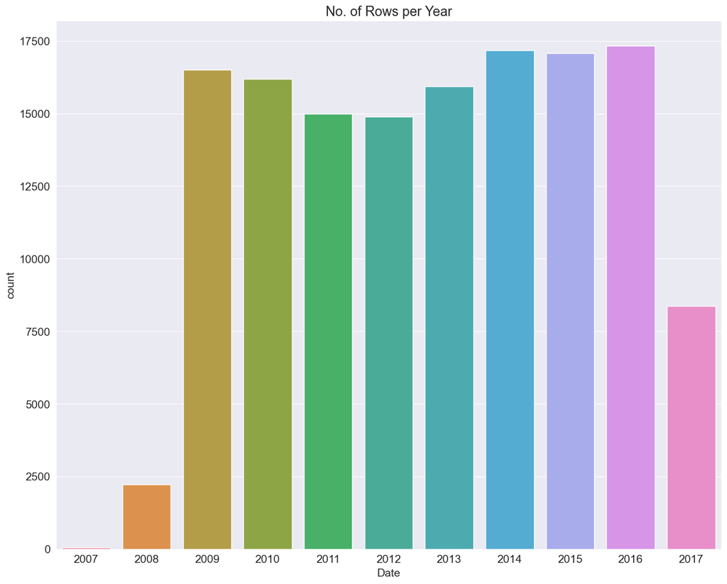

```python
plt.title('No. of Rows per Year')
sns.countplot(x=pd.to_datetime(df.Date).dt.year)
rcParams['figure.figsize'] = 10,6
plt.show()
```

```python
year = pd.to_datetime(df.Date).dt.year
```

```python
train_df = df[year < 2015]
val_df = df[year == 2015]
test_df = df[year > 2015]
```

```python
train_df
```

|  | Date | Location | MinTemp | MaxTemp | Rainfall | Evaporation | Sunshine | WindGustDir | WindGustSpeed | WindDir9am | ... | Humidity9am | Humidity3pm | Pressure9am | Pressure3pm | Cloud9am | Cloud3pm | Temp9am | Temp3pm | RainToday | RainTomorrow |
| --- | --- | --- | --- | --- | --- | --- | --- | --- | --- | --- | --- | --- | --- | --- | --- | --- | --- | --- | --- | --- | --- |
| 0 | 2008-12-01 | Albury | 13.4 | 22.9 | 0.6 | 5.472516 | 7.63054 | W | 44.0 | W | ... | 71.0 | 22.0 | 1007.7 | 1007.1 | 8.000000 | 4.49925 | 16.9 | 21.8 | No | No |
| 1 | 2008-12-02 | Albury | 7.4 | 25.1 | 0.0 | 5.472516 | 7.63054 | WNW | 44.0 | NNW | ... | 44.0 | 25.0 | 1010.6 | 1007.8 | 4.431161 | 4.49925 | 17.2 | 24.3 | No | No |
| 2 | 2008-12-03 | Albury | 12.9 | 25.7 | 0.0 | 5.472516 | 7.63054 | WSW | 46.0 | W | ... | 38.0 | 30.0 | 1007.6 | 1008.7 | 4.431161 | 2.00000 | 21.0 | 23.2 | No | No |
| 3 | 2008-12-04 | Albury | 9.2 | 28.0 | 0.0 | 5.472516 | 7.63054 | NE | 24.0 | SE | ... | 45.0 | 16.0 | 1017.6 | 1012.8 | 4.431161 | 4.49925 | 18.1 | 26.5 | No | No |
| 4 | 2008-12-05 | Albury | 17.5 | 32.3 | 1.0 | 5.472516 | 7.63054 | W | 41.0 | ENE | ... | 82.0 | 33.0 | 1010.8 | 1006.0 | 7.000000 | 8.00000 | 17.8 | 29.7 | No | No |
| ... | ... | ... | ... | ... | ... | ... | ... | ... | ... | ... | ... | ... | ... | ... | ... | ... | ... | ... | ... | ... | ... |
| 144548 | 2014-12-27 | Uluru | 16.9 | 33.2 | 0.0 | 5.472516 | 7.63054 | SSE | 43.0 | ESE | ... | 22.0 | 13.0 | 1014.1 | 1009.8 | 4.431161 | 4.49925 | 23.7 | 31.8 | No | No |
| 144549 | 2014-12-28 | Uluru | 15.1 | 36.8 | 0.0 | 5.472516 | 7.63054 | NE | 31.0 | ENE | ... | 16.0 | 8.0 | 1012.6 | 1007.6 | 4.431161 | 4.49925 | 28.9 | 34.8 | No | No |
| 144550 | 2014-12-29 | Uluru | 17.3 | 37.8 | 0.0 | 5.472516 | 7.63054 | ESE | 39.0 | ESE | ... | 15.0 | 8.0 | 1011.9 | 1008.0 | 4.431161 | 4.49925 | 29.7 | 35.7 | No | No |
| 144551 | 2014-12-30 | Uluru | 20.1 | 38.5 | 0.0 | 5.472516 | 7.63054 | ESE | 43.0 | ESE | ... | 22.0 | 9.0 | 1014.0 | 1009.2 | 4.431161 | 4.49925 | 29.8 | 37.2 | No | No |
| 144552 | 2014-12-31 | Uluru | 22.5 | 39.6 | 0.0 | 5.472516 | 7.63054 | WNW | 76.0 | ENE | ... | 16.0 | 9.0 | 1012.1 | 1006.2 | 4.431161 | 4.49925 | 30.1 | 37.4 | No | No |

97988 rows × 23 columns

```python
val_df
```

|  | Date | Location | MinTemp | MaxTemp | Rainfall | Evaporation | Sunshine | WindGustDir | WindGustSpeed | WindDir9am | ... | Humidity9am | Humidity3pm | Pressure9am | Pressure3pm | Cloud9am | Cloud3pm | Temp9am | Temp3pm | RainToday | RainTomorrow |
| --- | --- | --- | --- | --- | --- | --- | --- | --- | --- | --- | --- | --- | --- | --- | --- | --- | --- | --- | --- | --- | --- |
| 2133 | 2015-01-01 | Albury | 11.4 | 33.5 | 0.0 | 5.472516 | 7.63054 | WSW | 30.0 | ESE | ... | 45.0 | 14.0 | 1013.5 | 1011.0 | 4.431161 | 4.49925 | 21.0 | 32.7 | No | No |
| 2134 | 2015-01-02 | Albury | 15.5 | 39.6 | 0.0 | 5.472516 | 7.63054 | NE | 56.0 | ESE | ... | 45.0 | 12.0 | 1016.0 | 1012.4 | 4.431161 | 4.49925 | 25.6 | 38.2 | No | No |
| 2135 | 2015-01-03 | Albury | 17.1 | 38.3 | 0.0 | 5.472516 | 7.63054 | NNE | 48.0 | NE | ... | 35.0 | 19.0 | 1017.9 | 1012.3 | 4.431161 | 4.49925 | 29.2 | 37.0 | No | No |
| 2136 | 2015-01-04 | Albury | 26.0 | 33.1 | 0.0 | 5.472516 | 7.63054 | NNE | 41.0 | ESE | ... | 46.0 | 37.0 | 1013.6 | 1012.1 | 8.000000 | 5.00000 | 27.4 | 30.9 | No | No |
| 2137 | 2015-01-05 | Albury | 19.0 | 35.2 | 0.0 | 5.472516 | 7.63054 | E | 33.0 | SSE | ... | 60.0 | 34.0 | 1017.4 | 1014.7 | 8.000000 | 4.49925 | 25.6 | 32.5 | No | No |
| ... | ... | ... | ... | ... | ... | ... | ... | ... | ... | ... | ... | ... | ... | ... | ... | ... | ... | ... | ... | ... | ... |
| 144913 | 2015-12-27 | Uluru | 20.5 | 34.7 | 0.0 | 5.472516 | 7.63054 | E | 52.0 | ESE | ... | 23.0 | 12.0 | 1013.2 | 1010.1 | 4.431161 | 4.49925 | 24.3 | 33.0 | No | No |
| 144914 | 2015-12-28 | Uluru | 18.0 | 36.4 | 0.0 | 5.472516 | 7.63054 | ESE | 54.0 | E | ... | 17.0 | 7.0 | 1014.7 | 1010.9 | 4.431161 | 4.49925 | 26.7 | 35.0 | No | No |
| 144915 | 2015-12-29 | Uluru | 17.5 | 37.1 | 0.0 | 5.472516 | 7.63054 | E | 56.0 | E | ... | 12.0 | 7.0 | 1012.6 | 1007.5 | 4.431161 | 4.49925 | 28.1 | 34.7 | No | No |
| 144916 | 2015-12-30 | Uluru | 20.0 | 38.9 | 0.0 | 5.472516 | 7.63054 | E | 59.0 | E | ... | 12.0 | 12.0 | 1007.2 | 1002.6 | 4.431161 | 1.00000 | 31.3 | 38.4 | No | No |
| 144917 | 2015-12-31 | Uluru | 19.3 | 37.4 | 0.0 | 5.472516 | 7.63054 | SE | 56.0 | ESE | ... | 46.0 | 18.0 | 1007.3 | 1003.7 | 4.431161 | 4.49925 | 25.8 | 35.8 | No | No |

17089 rows × 23 columns

```python
test_df
```

|  | Date | Location | MinTemp | MaxTemp | Rainfall | Evaporation | Sunshine | WindGustDir | WindGustSpeed | WindDir9am | ... | Humidity9am | Humidity3pm | Pressure9am | Pressure3pm | Cloud9am | Cloud3pm | Temp9am | Temp3pm | RainToday | RainTomorrow |
| --- | --- | --- | --- | --- | --- | --- | --- | --- | --- | --- | --- | --- | --- | --- | --- | --- | --- | --- | --- | --- | --- |
| 2498 | 2016-01-01 | Albury | 20.4 | 37.6 | 0.0 | 5.472516 | 7.63054 | ENE | 54.0 | NaN | ... | 46.0 | 17.0 | 1013.4 | 1009.2 | 7.000000 | 3.00000 | 26.1 | 36.7 | No | No |
| 2499 | 2016-01-02 | Albury | 20.9 | 33.6 | 0.4 | 5.472516 | 7.63054 | SSE | 50.0 | SSE | ... | 54.0 | 30.0 | 1011.1 | 1008.4 | 8.000000 | 8.00000 | 24.8 | 31.7 | No | Yes |
| 2500 | 2016-01-03 | Albury | 18.4 | 23.1 | 2.2 | 5.472516 | 7.63054 | ENE | 48.0 | ESE | ... | 62.0 | 67.0 | 1014.0 | 1014.8 | 8.000000 | 8.00000 | 21.8 | 19.5 | Yes | Yes |
| 2501 | 2016-01-04 | Albury | 17.3 | 23.7 | 15.6 | 5.472516 | 7.63054 | SSE | 39.0 | SE | ... | 74.0 | 65.0 | 1017.9 | 1016.5 | 8.000000 | 8.00000 | 19.2 | 21.6 | Yes | Yes |
| 2502 | 2016-01-05 | Albury | 15.5 | 22.9 | 6.8 | 5.472516 | 7.63054 | ENE | 31.0 | SE | ... | 92.0 | 63.0 | 1016.3 | 1013.9 | 8.000000 | 8.00000 | 17.2 | 22.2 | Yes | No |
| ... | ... | ... | ... | ... | ... | ... | ... | ... | ... | ... | ... | ... | ... | ... | ... | ... | ... | ... | ... | ... | ... |
| 145454 | 2017-06-20 | Uluru | 3.5 | 21.8 | 0.0 | 5.472516 | 7.63054 | E | 31.0 | ESE | ... | 59.0 | 27.0 | 1024.7 | 1021.2 | 4.431161 | 4.49925 | 9.4 | 20.9 | No | No |
| 145455 | 2017-06-21 | Uluru | 2.8 | 23.4 | 0.0 | 5.472516 | 7.63054 | E | 31.0 | SE | ... | 51.0 | 24.0 | 1024.6 | 1020.3 | 4.431161 | 4.49925 | 10.1 | 22.4 | No | No |
| 145456 | 2017-06-22 | Uluru | 3.6 | 25.3 | 0.0 | 5.472516 | 7.63054 | NNW | 22.0 | SE | ... | 56.0 | 21.0 | 1023.5 | 1019.1 | 4.431161 | 4.49925 | 10.9 | 24.5 | No | No |
| 145457 | 2017-06-23 | Uluru | 5.4 | 26.9 | 0.0 | 5.472516 | 7.63054 | N | 37.0 | SE | ... | 53.0 | 24.0 | 1021.0 | 1016.8 | 4.431161 | 4.49925 | 12.5 | 26.1 | No | No |
| 145458 | 2017-06-24 | Uluru | 7.8 | 27.0 | 0.0 | 5.472516 | 7.63054 | SE | 28.0 | SSE | ... | 51.0 | 24.0 | 1019.4 | 1016.5 | 3.000000 | 2.00000 | 15.1 | 26.0 | No | No |

25710 rows × 23 columns

## Identifying Input and Target Columns

Often, not all the columns in a dataset are useful for training a model. In the current dataset, we can ignore the `Date` column, since we only want to weather conditions to make a prediction about whether it will rain the next day.

Let's create a list of input columns, and also identify the target column.

```python
input_col = list(train_df.columns[1:-1])
target_col = 'RainTomorrow'
```

```python
input_col
```

```
['Location',
 'MinTemp',
 'MaxTemp',
 'Rainfall',
 'Evaporation',
 'Sunshine',
 'WindGustDir',
 'WindGustSpeed',
 'WindDir9am',
 'WindDir3pm',
 'WindSpeed9am',
 'WindSpeed3pm',
 'Humidity9am',
 'Humidity3pm',
 'Pressure9am',
 'Pressure3pm',
 'Cloud9am',
 'Cloud3pm',
 'Temp9am',
 'Temp3pm',
 'RainToday']
```

```python
target_col
```

```
'RainTomorrow'
```

```python
train_inputs = train_df[input_col]
train_targets = train_df[target_col]
val_inputs = val_df[input_col]
val_targets = val_df[target_col]
test_inputs = test_df[input_col]
test_targets = test_df[target_col]
```

```python
train_inputs
```

|  | Location | MinTemp | MaxTemp | Rainfall | Evaporation | Sunshine | WindGustDir | WindGustSpeed | WindDir9am | WindDir3pm | ... | WindSpeed3pm | Humidity9am | Humidity3pm | Pressure9am | Pressure3pm | Cloud9am | Cloud3pm | Temp9am | Temp3pm | RainToday |
| --- | --- | --- | --- | --- | --- | --- | --- | --- | --- | --- | --- | --- | --- | --- | --- | --- | --- | --- | --- | --- | --- |
| 0 | Albury | 13.4 | 22.9 | 0.6 | 5.472516 | 7.63054 | W | 44.0 | W | WNW | ... | 24.0 | 71.0 | 22.0 | 1007.7 | 1007.1 | 8.000000 | 4.49925 | 16.9 | 21.8 | No |
| 1 | Albury | 7.4 | 25.1 | 0.0 | 5.472516 | 7.63054 | WNW | 44.0 | NNW | WSW | ... | 22.0 | 44.0 | 25.0 | 1010.6 | 1007.8 | 4.431161 | 4.49925 | 17.2 | 24.3 | No |
| 2 | Albury | 12.9 | 25.7 | 0.0 | 5.472516 | 7.63054 | WSW | 46.0 | W | WSW | ... | 26.0 | 38.0 | 30.0 | 1007.6 | 1008.7 | 4.431161 | 2.00000 | 21.0 | 23.2 | No |
| 3 | Albury | 9.2 | 28.0 | 0.0 | 5.472516 | 7.63054 | NE | 24.0 | SE | E | ... | 9.0 | 45.0 | 16.0 | 1017.6 | 1012.8 | 4.431161 | 4.49925 | 18.1 | 26.5 | No |
| 4 | Albury | 17.5 | 32.3 | 1.0 | 5.472516 | 7.63054 | W | 41.0 | ENE | NW | ... | 20.0 | 82.0 | 33.0 | 1010.8 | 1006.0 | 7.000000 | 8.00000 | 17.8 | 29.7 | No |
| ... | ... | ... | ... | ... | ... | ... | ... | ... | ... | ... | ... | ... | ... | ... | ... | ... | ... | ... | ... | ... | ... |
| 144548 | Uluru | 16.9 | 33.2 | 0.0 | 5.472516 | 7.63054 | SSE | 43.0 | ESE | SSE | ... | 26.0 | 22.0 | 13.0 | 1014.1 | 1009.8 | 4.431161 | 4.49925 | 23.7 | 31.8 | No |
| 144549 | Uluru | 15.1 | 36.8 | 0.0 | 5.472516 | 7.63054 | NE | 31.0 | ENE | SW | ... | 20.0 | 16.0 | 8.0 | 1012.6 | 1007.6 | 4.431161 | 4.49925 | 28.9 | 34.8 | No |
| 144550 | Uluru | 17.3 | 37.8 | 0.0 | 5.472516 | 7.63054 | ESE | 39.0 | ESE | SSE | ... | 9.0 | 15.0 | 8.0 | 1011.9 | 1008.0 | 4.431161 | 4.49925 | 29.7 | 35.7 | No |
| 144551 | Uluru | 20.1 | 38.5 | 0.0 | 5.472516 | 7.63054 | ESE | 43.0 | ESE | SSW | ... | 17.0 | 22.0 | 9.0 | 1014.0 | 1009.2 | 4.431161 | 4.49925 | 29.8 | 37.2 | No |
| 144552 | Uluru | 22.5 | 39.6 | 0.0 | 5.472516 | 7.63054 | WNW | 76.0 | ENE | SSW | ... | 13.0 | 16.0 | 9.0 | 1012.1 | 1006.2 | 4.431161 | 4.49925 | 30.1 | 37.4 | No |

97988 rows × 21 columns

```python
train_targets
```

```
0         No
1         No
2         No
3         No
4         No
          ..
144548    No
144549    No
144550    No
144551    No
144552    No
Name: RainTomorrow, Length: 97988, dtype: object
```

## Scaling Numeric Features

Another good practice is to scale numeric features to a small range of values e.g. $(0,1)$ or $(-1,1)$. Scaling numeric features ensures that no particular feature has a disproportionate impact on the model's loss. Optimization algorithms also work better in practice with smaller numbers.

The numeric columns in our dataset have varying ranges.

```python
from sklearn.preprocessing import MinMaxScaler
```

```python
scaler = MinMaxScaler()
```

```python
scaler.fit(df[num_cols])
```

```
MinMaxScaler()
```

```python
print('Minimum:')
list(scaler.data_min_)
```

```
Minimum:
```

```
[-8.5,
 -4.8,
 0.0,
 0.0,
 0.0,
 6.0,
 0.0,
 0.0,
 0.0,
 0.0,
 980.5,
 977.1,
 0.0,
 0.0,
 -7.2,
 -5.4]
```

```python
print('Maximum:')
list(scaler.data_max_)
```

```
Maximum:
```

```
[33.9,
 48.1,
 371.0,
 145.0,
 14.5,
 135.0,
 130.0,
 87.0,
 100.0,
 100.0,
 1041.0,
 1039.6,
 9.0,
 9.0,
 40.2,
 46.7]
```

We can now separately scale the training, validation and test sets using the `transform` method of `scaler`.

```python
train_inputs[num_cols] = scaler.transform(train_inputs[num_cols])
val_inputs[num_cols] = scaler.transform(val_inputs[num_cols])
test_inputs[num_cols] = scaler.transform(test_inputs[num_cols])
```

```python
train_inputs[num_cols].describe()
```

|  | MinTemp | MaxTemp | Rainfall | Evaporation | Sunshine | WindGustSpeed | WindSpeed9am | WindSpeed3pm | Humidity9am | Humidity3pm | Pressure9am | Pressure3pm | Cloud9am | Cloud3pm | Temp9am | Temp3pm |
| --- | --- | --- | --- | --- | --- | --- | --- | --- | --- | --- | --- | --- | --- | --- | --- | --- |
| count | 97988.000000 | 97988.000000 | 97988.000000 | 97988.000000 | 97988.000000 | 97988.000000 | 97988.000000 | 97988.000000 | 97988.000000 | 97988.000000 | 97988.000000 | 97988.000000 | 97988.000000 | 97988.000000 | 97988.000000 | 97988.000000 |
| mean | 0.483689 | 0.525947 | 0.006396 | 0.036949 | 0.525366 | 0.265107 | 0.108395 | 0.215668 | 0.686309 | 0.514693 | 0.612014 | 0.608705 | 0.483192 | 0.493693 | 0.507089 | 0.517103 |
| std | 0.149458 | 0.131904 | 0.022962 | 0.021628 | 0.200931 | 0.102420 | 0.068800 | 0.101424 | 0.189008 | 0.206376 | 0.111335 | 0.106611 | 0.255486 | 0.238028 | 0.134722 | 0.130726 |
| min | 0.000000 | 0.013233 | 0.000000 | 0.000000 | 0.000000 | 0.000000 | 0.000000 | 0.000000 | 0.000000 | 0.000000 | 0.000000 | 0.030400 | 0.000000 | 0.000000 | 0.027426 | 0.005758 |
| 25% | 0.377358 | 0.429112 | 0.000000 | 0.026207 | 0.517241 | 0.193798 | 0.053846 | 0.149425 | 0.570000 | 0.370000 | 0.543802 | 0.540800 | 0.333333 | 0.333333 | 0.409283 | 0.422265 |
| 50% | 0.478774 | 0.514178 | 0.000000 | 0.037741 | 0.526244 | 0.255814 | 0.100000 | 0.218391 | 0.690000 | 0.520000 | 0.614125 | 0.610527 | 0.492351 | 0.499917 | 0.502110 | 0.506718 |
| 75% | 0.591981 | 0.618147 | 0.002156 | 0.038621 | 0.634483 | 0.310078 | 0.146154 | 0.275862 | 0.830000 | 0.650000 | 0.682645 | 0.675200 | 0.666667 | 0.666667 | 0.601266 | 0.604607 |
| max | 1.000000 | 1.000000 | 1.000000 | 0.568276 | 0.986207 | 1.000000 | 0.669231 | 1.000000 | 1.000000 | 1.000000 | 1.000000 | 1.000000 | 1.000000 | 1.000000 | 1.000000 | 0.988484 |

```python
train_inputs[num_cols]
```

|  | MinTemp | MaxTemp | Rainfall | Evaporation | Sunshine | WindGustSpeed | WindSpeed9am | WindSpeed3pm | Humidity9am | Humidity3pm | Pressure9am | Pressure3pm | Cloud9am | Cloud3pm | Temp9am | Temp3pm |
| --- | --- | --- | --- | --- | --- | --- | --- | --- | --- | --- | --- | --- | --- | --- | --- | --- |
| 0 | 0.516509 | 0.523629 | 0.001617 | 0.037741 | 0.526244 | 0.294574 | 0.153846 | 0.275862 | 0.71 | 0.22 | 0.449587 | 0.4800 | 0.888889 | 0.499917 | 0.508439 | 0.522073 |
| 1 | 0.375000 | 0.565217 | 0.000000 | 0.037741 | 0.526244 | 0.294574 | 0.030769 | 0.252874 | 0.44 | 0.25 | 0.497521 | 0.4912 | 0.492351 | 0.499917 | 0.514768 | 0.570058 |
| 2 | 0.504717 | 0.576560 | 0.000000 | 0.037741 | 0.526244 | 0.310078 | 0.146154 | 0.298851 | 0.38 | 0.30 | 0.447934 | 0.5056 | 0.492351 | 0.222222 | 0.594937 | 0.548944 |
| 3 | 0.417453 | 0.620038 | 0.000000 | 0.037741 | 0.526244 | 0.139535 | 0.084615 | 0.103448 | 0.45 | 0.16 | 0.613223 | 0.5712 | 0.492351 | 0.499917 | 0.533755 | 0.612284 |
| 4 | 0.613208 | 0.701323 | 0.002695 | 0.037741 | 0.526244 | 0.271318 | 0.053846 | 0.229885 | 0.82 | 0.33 | 0.500826 | 0.4624 | 0.777778 | 0.888889 | 0.527426 | 0.673704 |
| ... | ... | ... | ... | ... | ... | ... | ... | ... | ... | ... | ... | ... | ... | ... | ... | ... |
| 144548 | 0.599057 | 0.718336 | 0.000000 | 0.037741 | 0.526244 | 0.286822 | 0.184615 | 0.298851 | 0.22 | 0.13 | 0.555372 | 0.5232 | 0.492351 | 0.499917 | 0.651899 | 0.714012 |
| 144549 | 0.556604 | 0.786389 | 0.000000 | 0.037741 | 0.526244 | 0.193798 | 0.146154 | 0.229885 | 0.16 | 0.08 | 0.530579 | 0.4880 | 0.492351 | 0.499917 | 0.761603 | 0.771593 |
| 144550 | 0.608491 | 0.805293 | 0.000000 | 0.037741 | 0.526244 | 0.255814 | 0.200000 | 0.103448 | 0.15 | 0.08 | 0.519008 | 0.4944 | 0.492351 | 0.499917 | 0.778481 | 0.788868 |
| 144551 | 0.674528 | 0.818526 | 0.000000 | 0.037741 | 0.526244 | 0.286822 | 0.215385 | 0.195402 | 0.22 | 0.09 | 0.553719 | 0.5136 | 0.492351 | 0.499917 | 0.780591 | 0.817658 |
| 144552 | 0.731132 | 0.839319 | 0.000000 | 0.037741 | 0.526244 | 0.542636 | 0.230769 | 0.149425 | 0.16 | 0.09 | 0.522314 | 0.4656 | 0.492351 | 0.499917 | 0.786920 | 0.821497 |

97988 rows × 16 columns

```python
val_inputs[num_cols]
```

|  | MinTemp | MaxTemp | Rainfall | Evaporation | Sunshine | WindGustSpeed | WindSpeed9am | WindSpeed3pm | Humidity9am | Humidity3pm | Pressure9am | Pressure3pm | Cloud9am | Cloud3pm | Temp9am | Temp3pm |
| --- | --- | --- | --- | --- | --- | --- | --- | --- | --- | --- | --- | --- | --- | --- | --- | --- |
| 2133 | 0.469340 | 0.724008 | 0.0 | 0.037741 | 0.526244 | 0.186047 | 0.053846 | 0.126437 | 0.45 | 0.14 | 0.545455 | 0.5424 | 0.492351 | 0.499917 | 0.594937 | 0.731286 |
| 2134 | 0.566038 | 0.839319 | 0.0 | 0.037741 | 0.526244 | 0.387597 | 0.069231 | 0.103448 | 0.45 | 0.12 | 0.586777 | 0.5648 | 0.492351 | 0.499917 | 0.691983 | 0.836852 |
| 2135 | 0.603774 | 0.814745 | 0.0 | 0.037741 | 0.526244 | 0.325581 | 0.153846 | 0.229885 | 0.35 | 0.19 | 0.618182 | 0.5632 | 0.492351 | 0.499917 | 0.767932 | 0.813820 |
| 2136 | 0.813679 | 0.716446 | 0.0 | 0.037741 | 0.526244 | 0.271318 | 0.053846 | 0.080460 | 0.46 | 0.37 | 0.547107 | 0.5600 | 0.888889 | 0.555556 | 0.729958 | 0.696737 |
| 2137 | 0.648585 | 0.756144 | 0.0 | 0.037741 | 0.526244 | 0.209302 | 0.053846 | 0.103448 | 0.60 | 0.34 | 0.609917 | 0.6016 | 0.888889 | 0.499917 | 0.691983 | 0.727447 |
| ... | ... | ... | ... | ... | ... | ... | ... | ... | ... | ... | ... | ... | ... | ... | ... | ... |
| 144913 | 0.683962 | 0.746692 | 0.0 | 0.037741 | 0.526244 | 0.356589 | 0.269231 | 0.229885 | 0.23 | 0.12 | 0.540496 | 0.5280 | 0.492351 | 0.499917 | 0.664557 | 0.737044 |
| 144914 | 0.625000 | 0.778828 | 0.0 | 0.037741 | 0.526244 | 0.372093 | 0.230769 | 0.356322 | 0.17 | 0.07 | 0.565289 | 0.5408 | 0.492351 | 0.499917 | 0.715190 | 0.775432 |
| 144915 | 0.613208 | 0.792060 | 0.0 | 0.037741 | 0.526244 | 0.387597 | 0.253846 | 0.252874 | 0.12 | 0.07 | 0.530579 | 0.4864 | 0.492351 | 0.499917 | 0.744726 | 0.769674 |
| 144916 | 0.672170 | 0.826087 | 0.0 | 0.037741 | 0.526244 | 0.410853 | 0.153846 | 0.195402 | 0.12 | 0.12 | 0.441322 | 0.4080 | 0.492351 | 0.111111 | 0.812236 | 0.840691 |
| 144917 | 0.655660 | 0.797732 | 0.0 | 0.037741 | 0.526244 | 0.387597 | 0.153846 | 0.321839 | 0.46 | 0.18 | 0.442975 | 0.4256 | 0.492351 | 0.499917 | 0.696203 | 0.790787 |

17089 rows × 16 columns

## Encoding Categorical Data

Since machine learning models can only be trained with numeric data, we need to convert categorical data to numbers. A common technique is to use one-hot encoding for categorical columns.

[figure not shown]

One hot encoding involves adding a new binary (0/1) column for each unique category of a categorical column.

```python
df_raintm_dropped = df.drop(columns = 'RainTomorrow' , axis= 1)
```

```python
df_raintm_dropped
```

|  | Date | Location | MinTemp | MaxTemp | Rainfall | Evaporation | Sunshine | WindGustDir | WindGustSpeed | WindDir9am | ... | WindSpeed3pm | Humidity9am | Humidity3pm | Pressure9am | Pressure3pm | Cloud9am | Cloud3pm | Temp9am | Temp3pm | RainToday |
| --- | --- | --- | --- | --- | --- | --- | --- | --- | --- | --- | --- | --- | --- | --- | --- | --- | --- | --- | --- | --- | --- |
| 0 | 2008-12-01 | Albury | 13.4 | 22.9 | 0.6 | 5.472516 | 7.63054 | W | 44.0 | W | ... | 24.0 | 71.0 | 22.0 | 1007.7 | 1007.1 | 8.000000 | 4.49925 | 16.9 | 21.8 | No |
| 1 | 2008-12-02 | Albury | 7.4 | 25.1 | 0.0 | 5.472516 | 7.63054 | WNW | 44.0 | NNW | ... | 22.0 | 44.0 | 25.0 | 1010.6 | 1007.8 | 4.431161 | 4.49925 | 17.2 | 24.3 | No |
| 2 | 2008-12-03 | Albury | 12.9 | 25.7 | 0.0 | 5.472516 | 7.63054 | WSW | 46.0 | W | ... | 26.0 | 38.0 | 30.0 | 1007.6 | 1008.7 | 4.431161 | 2.00000 | 21.0 | 23.2 | No |
| 3 | 2008-12-04 | Albury | 9.2 | 28.0 | 0.0 | 5.472516 | 7.63054 | NE | 24.0 | SE | ... | 9.0 | 45.0 | 16.0 | 1017.6 | 1012.8 | 4.431161 | 4.49925 | 18.1 | 26.5 | No |
| 4 | 2008-12-05 | Albury | 17.5 | 32.3 | 1.0 | 5.472516 | 7.63054 | W | 41.0 | ENE | ... | 20.0 | 82.0 | 33.0 | 1010.8 | 1006.0 | 7.000000 | 8.00000 | 17.8 | 29.7 | No |
| ... | ... | ... | ... | ... | ... | ... | ... | ... | ... | ... | ... | ... | ... | ... | ... | ... | ... | ... | ... | ... | ... |
| 145454 | 2017-06-20 | Uluru | 3.5 | 21.8 | 0.0 | 5.472516 | 7.63054 | E | 31.0 | ESE | ... | 13.0 | 59.0 | 27.0 | 1024.7 | 1021.2 | 4.431161 | 4.49925 | 9.4 | 20.9 | No |
| 145455 | 2017-06-21 | Uluru | 2.8 | 23.4 | 0.0 | 5.472516 | 7.63054 | E | 31.0 | SE | ... | 11.0 | 51.0 | 24.0 | 1024.6 | 1020.3 | 4.431161 | 4.49925 | 10.1 | 22.4 | No |
| 145456 | 2017-06-22 | Uluru | 3.6 | 25.3 | 0.0 | 5.472516 | 7.63054 | NNW | 22.0 | SE | ... | 9.0 | 56.0 | 21.0 | 1023.5 | 1019.1 | 4.431161 | 4.49925 | 10.9 | 24.5 | No |
| 145457 | 2017-06-23 | Uluru | 5.4 | 26.9 | 0.0 | 5.472516 | 7.63054 | N | 37.0 | SE | ... | 9.0 | 53.0 | 24.0 | 1021.0 | 1016.8 | 4.431161 | 4.49925 | 12.5 | 26.1 | No |
| 145458 | 2017-06-24 | Uluru | 7.8 | 27.0 | 0.0 | 5.472516 | 7.63054 | SE | 28.0 | SSE | ... | 7.0 | 51.0 | 24.0 | 1019.4 | 1016.5 | 3.000000 | 2.00000 | 15.1 | 26.0 | No |

140787 rows × 22 columns

```python
from sklearn.preprocessing import OneHotEncoder
```

```python
encoder = OneHotEncoder(sparse=False, handle_unknown='ignore')
```

```python
encoder.fit(df[cat_col])
```

```
OneHotEncoder(handle_unknown='ignore', sparse=False, sparse_output=False)
```

```python
encoder.categories_
```

```
[array(['Adelaide', 'Albany', 'Albury', 'AliceSprings', 'BadgerysCreek',
        'Ballarat', 'Bendigo', 'Brisbane', 'Cairns', 'Canberra', 'Cobar',
        'CoffsHarbour', 'Dartmoor', 'Darwin', 'GoldCoast', 'Hobart',
        'Katherine', 'Launceston', 'Melbourne', 'MelbourneAirport',
        'Mildura', 'Moree', 'MountGambier', 'MountGinini', 'Newcastle',
        'Nhil', 'NorahHead', 'NorfolkIsland', 'Nuriootpa', 'PearceRAAF',
        'Penrith', 'Perth', 'PerthAirport', 'Portland', 'Richmond', 'Sale',
        'SalmonGums', 'Sydney', 'SydneyAirport', 'Townsville',
        'Tuggeranong', 'Uluru', 'WaggaWagga', 'Walpole', 'Watsonia',
        'Williamtown', 'Witchcliffe', 'Wollongong', 'Woomera'],
       dtype=object),
 array(['E', 'ENE', 'ESE', 'N', 'NE', 'NNE', 'NNW', 'NW', 'S', 'SE', 'SSE',
        'SSW', 'SW', 'W', 'WNW', 'WSW', nan], dtype=object),
 array(['E', 'ENE', 'ESE', 'N', 'NE', 'NNE', 'NNW', 'NW', 'S', 'SE', 'SSE',
        'SSW', 'SW', 'W', 'WNW', 'WSW', nan], dtype=object),
 array(['E', 'ENE', 'ESE', 'N', 'NE', 'NNE', 'NNW', 'NW', 'S', 'SE', 'SSE',
        'SSW', 'SW', 'W', 'WNW', 'WSW', nan], dtype=object),
 array(['No', 'Yes'], dtype=object)]
```

The encoder has created a list of categories for each of the categorical columns in the dataset.

We can generate column names for each individual category using `get_feature_names_out`.

```python
encoded_cols = list(encoder.get_feature_names_out(cat_col))
print(encoded_cols)
```

```
['Location_Adelaide', 'Location_Albany', 'Location_Albury', 'Location_AliceSprings', 'Location_BadgerysCreek', 'Location_Ballarat', 'Location_Bendigo', 'Location_Brisbane', 'Location_Cairns', 'Location_Canberra', 'Location_Cobar', 'Location_CoffsHarbour', 'Location_Dartmoor', 'Location_Darwin', 'Loc…
```

```python
train_inputs[encoded_cols] = encoder.transform(train_inputs[cat_col])
val_inputs[encoded_cols]  = encoder.transform(val_inputs[cat_col])
test_inputs[encoded_cols]  = encoder.transform(test_inputs[cat_col])
```

```python
pd.set_option('display.max_columns', None)
```

```python
train_inputs
```

|  | Location | MinTemp | MaxTemp | Rainfall | Evaporation | Sunshine | WindGustDir | WindGustSpeed | WindDir9am | WindDir3pm | WindSpeed9am | WindSpeed3pm | Humidity9am | Humidity3pm | Pressure9am | Pressure3pm | Cloud9am | Cloud3pm | Temp9am | Temp3pm | RainToday | Location_Adelaide | Location_Albany | Location_Albury | Location_AliceSprings | Location_BadgerysCreek | Location_Ballarat | Location_Bendigo | Location_Brisbane | … |
| --- | --- | --- | --- | --- | --- | --- | --- | --- | --- | --- | --- | --- | --- | --- | --- | --- | --- | --- | --- | --- | --- | --- | --- | --- | --- | --- | --- | --- | --- | --- |
| 0 | Albury | 0.516509 | 0.523629 | 0.001617 | 0.037741 | 0.526244 | W | 0.294574 | W | WNW | 0.153846 | 0.275862 | 0.71 | 0.22 | 0.449587 | 0.4800 | 0.888889 | 0.499917 | 0.508439 | 0.522073 | No | 0.0 | 0.0 | 1.0 | 0.0 | 0.0 | 0.0 | 0.0 | 0.0 | … |
| 1 | Albury | 0.375000 | 0.565217 | 0.000000 | 0.037741 | 0.526244 | WNW | 0.294574 | NNW | WSW | 0.030769 | 0.252874 | 0.44 | 0.25 | 0.497521 | 0.4912 | 0.492351 | 0.499917 | 0.514768 | 0.570058 | No | 0.0 | 0.0 | 1.0 | 0.0 | 0.0 | 0.0 | 0.0 | 0.0 | … |
| 2 | Albury | 0.504717 | 0.576560 | 0.000000 | 0.037741 | 0.526244 | WSW | 0.310078 | W | WSW | 0.146154 | 0.298851 | 0.38 | 0.30 | 0.447934 | 0.5056 | 0.492351 | 0.222222 | 0.594937 | 0.548944 | No | 0.0 | 0.0 | 1.0 | 0.0 | 0.0 | 0.0 | 0.0 | 0.0 | … |
| 3 | Albury | 0.417453 | 0.620038 | 0.000000 | 0.037741 | 0.526244 | NE | 0.139535 | SE | E | 0.084615 | 0.103448 | 0.45 | 0.16 | 0.613223 | 0.5712 | 0.492351 | 0.499917 | 0.533755 | 0.612284 | No | 0.0 | 0.0 | 1.0 | 0.0 | 0.0 | 0.0 | 0.0 | 0.0 | … |
| 4 | Albury | 0.613208 | 0.701323 | 0.002695 | 0.037741 | 0.526244 | W | 0.271318 | ENE | NW | 0.053846 | 0.229885 | 0.82 | 0.33 | 0.500826 | 0.4624 | 0.777778 | 0.888889 | 0.527426 | 0.673704 | No | 0.0 | 0.0 | 1.0 | 0.0 | 0.0 | 0.0 | 0.0 | 0.0 | … |
| ... | ... | ... | ... | ... | ... | ... | ... | ... | ... | ... | ... | ... | ... | ... | ... | ... | ... | ... | ... | ... | ... | ... | ... | ... | ... | ... | ... | ... | ... | … |
| 144548 | Uluru | 0.599057 | 0.718336 | 0.000000 | 0.037741 | 0.526244 | SSE | 0.286822 | ESE | SSE | 0.184615 | 0.298851 | 0.22 | 0.13 | 0.555372 | 0.5232 | 0.492351 | 0.499917 | 0.651899 | 0.714012 | No | 0.0 | 0.0 | 0.0 | 0.0 | 0.0 | 0.0 | 0.0 | 0.0 | … |
| 144549 | Uluru | 0.556604 | 0.786389 | 0.000000 | 0.037741 | 0.526244 | NE | 0.193798 | ENE | SW | 0.146154 | 0.229885 | 0.16 | 0.08 | 0.530579 | 0.4880 | 0.492351 | 0.499917 | 0.761603 | 0.771593 | No | 0.0 | 0.0 | 0.0 | 0.0 | 0.0 | 0.0 | 0.0 | 0.0 | … |
| 144550 | Uluru | 0.608491 | 0.805293 | 0.000000 | 0.037741 | 0.526244 | ESE | 0.255814 | ESE | SSE | 0.200000 | 0.103448 | 0.15 | 0.08 | 0.519008 | 0.4944 | 0.492351 | 0.499917 | 0.778481 | 0.788868 | No | 0.0 | 0.0 | 0.0 | 0.0 | 0.0 | 0.0 | 0.0 | 0.0 | … |
| 144551 | Uluru | 0.674528 | 0.818526 | 0.000000 | 0.037741 | 0.526244 | ESE | 0.286822 | ESE | SSW | 0.215385 | 0.195402 | 0.22 | 0.09 | 0.553719 | 0.5136 | 0.492351 | 0.499917 | 0.780591 | 0.817658 | No | 0.0 | 0.0 | 0.0 | 0.0 | 0.0 | 0.0 | 0.0 | 0.0 | … |
| 144552 | Uluru | 0.731132 | 0.839319 | 0.000000 | 0.037741 | 0.526244 | WNW | 0.542636 | ENE | SSW | 0.230769 | 0.149425 | 0.16 | 0.09 | 0.522314 | 0.4656 | 0.492351 | 0.499917 | 0.786920 | 0.821497 | No | 0.0 | 0.0 | 0.0 | 0.0 | 0.0 | 0.0 | 0.0 | 0.0 | … |

97988 rows × 123 columns

```python
test_inputs
```

|  | Location | MinTemp | MaxTemp | Rainfall | Evaporation | Sunshine | WindGustDir | WindGustSpeed | WindDir9am | WindDir3pm | WindSpeed9am | WindSpeed3pm | Humidity9am | Humidity3pm | Pressure9am | Pressure3pm | Cloud9am | Cloud3pm | Temp9am | Temp3pm | RainToday | Location_Adelaide | Location_Albany | Location_Albury | Location_AliceSprings | Location_BadgerysCreek | Location_Ballarat | Location_Bendigo | Location_Brisbane | … |
| --- | --- | --- | --- | --- | --- | --- | --- | --- | --- | --- | --- | --- | --- | --- | --- | --- | --- | --- | --- | --- | --- | --- | --- | --- | --- | --- | --- | --- | --- | --- |
| 2498 | Albury | 0.681604 | 0.801512 | 0.000000 | 0.037741 | 0.526244 | ENE | 0.372093 | NaN | ESE | 0.000000 | 0.080460 | 0.46 | 0.17 | 0.543802 | 0.5136 | 0.777778 | 0.333333 | 0.702532 | 0.808061 | No | 0.0 | 0.0 | 1.0 | 0.0 | 0.0 | 0.0 | 0.0 | 0.0 | … |
| 2499 | Albury | 0.693396 | 0.725898 | 0.001078 | 0.037741 | 0.526244 | SSE | 0.341085 | SSE | SE | 0.069231 | 0.195402 | 0.54 | 0.30 | 0.505785 | 0.5008 | 0.888889 | 0.888889 | 0.675105 | 0.712092 | No | 0.0 | 0.0 | 1.0 | 0.0 | 0.0 | 0.0 | 0.0 | 0.0 | … |
| 2500 | Albury | 0.634434 | 0.527410 | 0.005930 | 0.037741 | 0.526244 | ENE | 0.325581 | ESE | ENE | 0.084615 | 0.448276 | 0.62 | 0.67 | 0.553719 | 0.6032 | 0.888889 | 0.888889 | 0.611814 | 0.477927 | Yes | 0.0 | 0.0 | 1.0 | 0.0 | 0.0 | 0.0 | 0.0 | 0.0 | … |
| 2501 | Albury | 0.608491 | 0.538752 | 0.042049 | 0.037741 | 0.526244 | SSE | 0.255814 | SE | SSE | 0.069231 | 0.195402 | 0.74 | 0.65 | 0.618182 | 0.6304 | 0.888889 | 0.888889 | 0.556962 | 0.518234 | Yes | 0.0 | 0.0 | 1.0 | 0.0 | 0.0 | 0.0 | 0.0 | 0.0 | … |
| 2502 | Albury | 0.566038 | 0.523629 | 0.018329 | 0.037741 | 0.526244 | ENE | 0.193798 | SE | SSE | 0.046154 | 0.103448 | 0.92 | 0.63 | 0.591736 | 0.5888 | 0.888889 | 0.888889 | 0.514768 | 0.529750 | Yes | 0.0 | 0.0 | 1.0 | 0.0 | 0.0 | 0.0 | 0.0 | 0.0 | … |
| ... | ... | ... | ... | ... | ... | ... | ... | ... | ... | ... | ... | ... | ... | ... | ... | ... | ... | ... | ... | ... | ... | ... | ... | ... | ... | ... | ... | ... | ... | … |
| 145454 | Uluru | 0.283019 | 0.502836 | 0.000000 | 0.037741 | 0.526244 | E | 0.193798 | ESE | E | 0.115385 | 0.149425 | 0.59 | 0.27 | 0.730579 | 0.7056 | 0.492351 | 0.499917 | 0.350211 | 0.504798 | No | 0.0 | 0.0 | 0.0 | 0.0 | 0.0 | 0.0 | 0.0 | 0.0 | … |
| 145455 | Uluru | 0.266509 | 0.533081 | 0.000000 | 0.037741 | 0.526244 | E | 0.193798 | SE | ENE | 0.100000 | 0.126437 | 0.51 | 0.24 | 0.728926 | 0.6912 | 0.492351 | 0.499917 | 0.364979 | 0.533589 | No | 0.0 | 0.0 | 0.0 | 0.0 | 0.0 | 0.0 | 0.0 | 0.0 | … |
| 145456 | Uluru | 0.285377 | 0.568998 | 0.000000 | 0.037741 | 0.526244 | NNW | 0.124031 | SE | N | 0.100000 | 0.103448 | 0.56 | 0.21 | 0.710744 | 0.6720 | 0.492351 | 0.499917 | 0.381857 | 0.573896 | No | 0.0 | 0.0 | 0.0 | 0.0 | 0.0 | 0.0 | 0.0 | 0.0 | … |
| 145457 | Uluru | 0.327830 | 0.599244 | 0.000000 | 0.037741 | 0.526244 | N | 0.240310 | SE | WNW | 0.069231 | 0.103448 | 0.53 | 0.24 | 0.669421 | 0.6352 | 0.492351 | 0.499917 | 0.415612 | 0.604607 | No | 0.0 | 0.0 | 0.0 | 0.0 | 0.0 | 0.0 | 0.0 | 0.0 | … |
| 145458 | Uluru | 0.384434 | 0.601134 | 0.000000 | 0.037741 | 0.526244 | SE | 0.170543 | SSE | N | 0.100000 | 0.080460 | 0.51 | 0.24 | 0.642975 | 0.6304 | 0.333333 | 0.222222 | 0.470464 | 0.602687 | No | 0.0 | 0.0 | 0.0 | 0.0 | 0.0 | 0.0 | 0.0 | 0.0 | … |

25710 rows × 123 columns

```python
val_inputs
```

|  | Location | MinTemp | MaxTemp | Rainfall | Evaporation | Sunshine | WindGustDir | WindGustSpeed | WindDir9am | WindDir3pm | WindSpeed9am | WindSpeed3pm | Humidity9am | Humidity3pm | Pressure9am | Pressure3pm | Cloud9am | Cloud3pm | Temp9am | Temp3pm | RainToday | Location_Adelaide | Location_Albany | Location_Albury | Location_AliceSprings | Location_BadgerysCreek | Location_Ballarat | Location_Bendigo | Location_Brisbane | … |
| --- | --- | --- | --- | --- | --- | --- | --- | --- | --- | --- | --- | --- | --- | --- | --- | --- | --- | --- | --- | --- | --- | --- | --- | --- | --- | --- | --- | --- | --- | --- |
| 2133 | Albury | 0.469340 | 0.724008 | 0.0 | 0.037741 | 0.526244 | WSW | 0.186047 | ESE | W | 0.053846 | 0.126437 | 0.45 | 0.14 | 0.545455 | 0.5424 | 0.492351 | 0.499917 | 0.594937 | 0.731286 | No | 0.0 | 0.0 | 1.0 | 0.0 | 0.0 | 0.0 | 0.0 | 0.0 | … |
| 2134 | Albury | 0.566038 | 0.839319 | 0.0 | 0.037741 | 0.526244 | NE | 0.387597 | ESE | ESE | 0.069231 | 0.103448 | 0.45 | 0.12 | 0.586777 | 0.5648 | 0.492351 | 0.499917 | 0.691983 | 0.836852 | No | 0.0 | 0.0 | 1.0 | 0.0 | 0.0 | 0.0 | 0.0 | 0.0 | … |
| 2135 | Albury | 0.603774 | 0.814745 | 0.0 | 0.037741 | 0.526244 | NNE | 0.325581 | NE | N | 0.153846 | 0.229885 | 0.35 | 0.19 | 0.618182 | 0.5632 | 0.492351 | 0.499917 | 0.767932 | 0.813820 | No | 0.0 | 0.0 | 1.0 | 0.0 | 0.0 | 0.0 | 0.0 | 0.0 | … |
| 2136 | Albury | 0.813679 | 0.716446 | 0.0 | 0.037741 | 0.526244 | NNE | 0.271318 | ESE | W | 0.053846 | 0.080460 | 0.46 | 0.37 | 0.547107 | 0.5600 | 0.888889 | 0.555556 | 0.729958 | 0.696737 | No | 0.0 | 0.0 | 1.0 | 0.0 | 0.0 | 0.0 | 0.0 | 0.0 | … |
| 2137 | Albury | 0.648585 | 0.756144 | 0.0 | 0.037741 | 0.526244 | E | 0.209302 | SSE | SE | 0.053846 | 0.103448 | 0.60 | 0.34 | 0.609917 | 0.6016 | 0.888889 | 0.499917 | 0.691983 | 0.727447 | No | 0.0 | 0.0 | 1.0 | 0.0 | 0.0 | 0.0 | 0.0 | 0.0 | … |
| ... | ... | ... | ... | ... | ... | ... | ... | ... | ... | ... | ... | ... | ... | ... | ... | ... | ... | ... | ... | ... | ... | ... | ... | ... | ... | ... | ... | ... | ... | … |
| 144913 | Uluru | 0.683962 | 0.746692 | 0.0 | 0.037741 | 0.526244 | E | 0.356589 | ESE | E | 0.269231 | 0.229885 | 0.23 | 0.12 | 0.540496 | 0.5280 | 0.492351 | 0.499917 | 0.664557 | 0.737044 | No | 0.0 | 0.0 | 0.0 | 0.0 | 0.0 | 0.0 | 0.0 | 0.0 | … |
| 144914 | Uluru | 0.625000 | 0.778828 | 0.0 | 0.037741 | 0.526244 | ESE | 0.372093 | E | ESE | 0.230769 | 0.356322 | 0.17 | 0.07 | 0.565289 | 0.5408 | 0.492351 | 0.499917 | 0.715190 | 0.775432 | No | 0.0 | 0.0 | 0.0 | 0.0 | 0.0 | 0.0 | 0.0 | 0.0 | … |
| 144915 | Uluru | 0.613208 | 0.792060 | 0.0 | 0.037741 | 0.526244 | E | 0.387597 | E | SE | 0.253846 | 0.252874 | 0.12 | 0.07 | 0.530579 | 0.4864 | 0.492351 | 0.499917 | 0.744726 | 0.769674 | No | 0.0 | 0.0 | 0.0 | 0.0 | 0.0 | 0.0 | 0.0 | 0.0 | … |
| 144916 | Uluru | 0.672170 | 0.826087 | 0.0 | 0.037741 | 0.526244 | E | 0.410853 | E | SSE | 0.153846 | 0.195402 | 0.12 | 0.12 | 0.441322 | 0.4080 | 0.492351 | 0.111111 | 0.812236 | 0.840691 | No | 0.0 | 0.0 | 0.0 | 0.0 | 0.0 | 0.0 | 0.0 | 0.0 | … |
| 144917 | Uluru | 0.655660 | 0.797732 | 0.0 | 0.037741 | 0.526244 | SE | 0.387597 | ESE | S | 0.153846 | 0.321839 | 0.46 | 0.18 | 0.442975 | 0.4256 | 0.492351 | 0.499917 | 0.696203 | 0.790787 | No | 0.0 | 0.0 | 0.0 | 0.0 | 0.0 | 0.0 | 0.0 | 0.0 | … |

17089 rows × 123 columns

## Saving Processed Data to Disk

```python
print('train_inputs:', train_inputs.shape)
print('train_targets:', train_targets.shape)
print('val_inputs:', val_inputs.shape)
print('val_targets:', val_targets.shape)
print('test_inputs:', test_inputs.shape)
print('test_targets:', test_targets.shape)
```

```
train_inputs: (97988, 123)
train_targets: (97988,)
val_inputs: (17089, 123)
val_targets: (17089,)
test_inputs: (25710, 123)
test_targets: (25710,)
```

```python
train_inputs.to_csv('Preprocessed csv files\\train_inputs.csv' , index=False)
val_inputs.to_csv('Preprocessed csv files\\val_inputs.csv' , index=False)
test_inputs.to_csv('Preprocessed csv files\\test_inputs.csv', index=False)
```

```python
pd.DataFrame(train_targets).to_csv('Preprocessed csv files\\train_targets.csv', index=False)
pd.DataFrame(val_targets).to_csv('Preprocessed csv files\\val_targets.csv', index=False)
pd.DataFrame(test_targets).to_csv('Preprocessed csv files\\test_targets.csv', index=False)
```

## importing data from local disk

```python
train_inputs = pd.read_csv('Preprocessed csv files\\train_inputs.csv')
val_inputs = pd.read_csv('Preprocessed csv files\\val_inputs.csv')
test_inputs = pd.read_csv('Preprocessed csv files\\test_inputs.csv')

train_targets = pd.read_csv('Preprocessed csv files\\train_targets.csv')[target_col]
val_targets = pd.read_csv('Preprocessed csv files\\val_targets.csv')[target_col]
test_targets = pd.read_csv('Preprocessed csv files\\test_targets.csv')[target_col]
```

```python
print('train_inputs:', train_inputs.shape)
print('train_targets:', train_targets.shape)
print('val_inputs:', val_inputs.shape)
print('val_targets:', val_targets.shape)
print('test_inputs:', test_inputs.shape)
print('test_targets:', test_targets.shape)
```

```
train_inputs: (97988, 123)
train_targets: (97988,)
val_inputs: (17089, 123)
val_targets: (17089,)
test_inputs: (25710, 123)
test_targets: (25710,)
```

## Training a Logistic Regression Model

Logistic regression is a commonly used technique for solving binary classification problems. In a logistic regression model:

- we take linear combination (or weighted sum of the input features)
- we apply the sigmoid function to the result to obtain a number between 0 and 1
- this number represents the probability of the input being classified as "Yes"
- instead of RMSE, the cross entropy loss function is used to evaluate the results

Here's a visual summary of how a logistic regression model is structured ([source](http://datahacker.rs/005-pytorch-logistic-regression-in-pytorch/)):

[figure not shown]

The sigmoid function applied to the linear combination of inputs has the following formula:

[figure not shown]

To train a logistic regression model, we can use the `LogisticRegression` class from Scikit-learn.

```python
from sklearn.linear_model import LogisticRegression
```

```python
?LogisticRegression
```

[output not shown]

[output cut: 249 more lines]

```
--------
>>> from sklearn.datasets import load_iris
>>> from sklearn.linear_model import LogisticRegression
>>> X, y = load_iris(return_X_y=True)
>>> clf = LogisticRegression(random_state=0).fit(X, y)
>>> clf.predict(X[:2, :])
array([0, 0])
>>> clf.predict_proba(X[:2, :])
array([[9.8...e-01, 1.8...e-02, 1.4...e-08],
       [9.7...e-01, 2.8...e-02, ...e-08]])
>>> clf.score(X, y)
0.97...
File:           c:\users\saket\anaconda3\lib\site-packages\sklearn\linear_model\_logistic.py
Type:           type
Subclasses:     LogisticRegressionCV
```

```python
model = LogisticRegression(solver='liblinear')
```

```python
model.fit(train_inputs[num_cols+encoded_cols] , train_targets)
```

```
LogisticRegression(solver='liblinear')
```

`model.fit` uses the following workflow for training the model ([source](https://www.deepnetts.com/blog/from-basic-machine-learning-to-deep-learning-in-5-minutes.html)):

1. We initialize a model with random parameters (weights & biases).
2. We pass some inputs into the model to obtain predictions.
3. We compare the model's predictions with the actual targets using the loss function.
4. We use an optimization technique (like least squares, gradient descent etc.) to reduce the loss by adjusting the weights & biases of the model
5. We repeat steps 1 to 4 till the predictions from the model are good enough.

[figure not shown]

For a mathematical discussion of logistic regression, sigmoid activation and cross entropy, check out [this YouTube playlist](https://www.youtube.com/watch?v=-la3q9d7AKQ&list=PLNeKWBMsAzboR8vvhnlanxCNr2V7ITuxy&index=1). Logistic regression can also be applied to multi-class classification problems, with a few modifications.

```python
print(num_cols + encoded_cols)
```

```
['MinTemp', 'MaxTemp', 'Rainfall', 'Evaporation', 'Sunshine', 'WindGustSpeed', 'WindSpeed9am', 'WindSpeed3pm', 'Humidity9am', 'Humidity3pm', 'Pressure9am', 'Pressure3pm', 'Cloud9am', 'Cloud3pm', 'Temp9am', 'Temp3pm', 'Location_Adelaide', 'Location_Albany', 'Location_Albury', 'Location_AliceSprings',…
```

```python
print(model.coef_)
```

```
[[ 8.98631132e-01 -2.87991510e+00  3.16277763e+00  8.54246046e-01
  -1.67139389e+00  6.76440060e+00 -9.42321465e-01 -1.42842873e+00
   3.22892861e-01  5.99531535e+00  5.46385654e+00 -9.17680464e+00
  -1.62297240e-01  1.28765969e+00  4.74715338e-01  2.02142985e+00
   6.01650247e-01 -5.52481891e-01  4.78142839e-01  7.66950214e-03
   3.46814566e-01 -3.52277298e-01  1.79710762e-01  4.40486476e-01
  -1.39816993e-02  2.89438374e-02  2.58147353e-01 -2.12056098e-02
  -4.27948813e-02 -4.83141626e-01 -1.37563367e-01 -5.76059708e-01
  -7.87523135e-01 -2.55404001e-01 -3.28884062e-01 -5.69004549e-01
   8.18300108e-02  1.33824722e-02  6.41274415e-02 -9.02054572e-01
  -4.44329703e-01  8.51718291e-03 -4.60612389e-01 -4.65518112e-01
  -6.94990050e-02  1.91158755e-01  4.50475925e-01  6.08121045e-01
   4.27313825e-01 -2.83312782e-02  2.51546810e-01 -3.21605692e-01
   4.24955919e-01 -5.90373141e-02 -1.13200360e-01 -7.28377003e-01
   3.66452691e-01  1.83590380e-01  1.83975097e-01  1.86604116e-01
  -2.49269523e-01  1.79481510e-02  7.03402910e-01 -8.00021435e-01
  -1.92344271e-01 -1.61797912e-01 -1.58986175e-01 -6.31003400e-02
  -2.23550795e-01 -2.32392874e-01 -3.21152784e-01 -1.65568935e-01
  -1.58849017e-01 -1.10976094e-01 -3.25274006e-02 -5.06277141e-02
  -9.41990620e-02 -9.08177155e-02 -2.23155538e-01 -2.58528346e-01
  -2.00815540e-01  9.74920754e-02 -3.18773723e-01 -2.93565868e-02
  -3.28613736e-01  2.98652338e-02 -2.10660884e-02  1.44052909e-01
  -6.17689478e-02 -5.69745089e-02 -4.08535961e-01 -3.08123542e-01
  -4.05434917e-01 -1.94829486e-01 -6.02914534e-02 -8.69207654e-02
  -5.71125231e-02 -1.61294236e-02 -2.69540650e-01 -2.39853725e-01
  -1.52500763e-01 -2.34834134e-01  3.81965143e-02 -3.11413231e-01
  -8.02448813e-02  2.84545812e-01  2.21850829e-01 -2.65449080e-01
  -2.41174140e-01 -3.66880829e-01 -3.16862729e-01 -3.70021766e-01
  -1.80370430e-01 -3.34990664e-02 -2.75975634e-01  7.49330860e-02
  -1.47351679e+00 -9.76037379e-01]]
```

```python
print(model.intercept_)
```

```
[-2.44955417]
```

## Making Predictions and Evaluating the Model

```python
X_train = train_inputs[num_cols + encoded_cols]
X_val = val_inputs[num_cols + encoded_cols]
X_test = test_inputs[num_cols + encoded_cols]
```

```python
train_preds = model.predict(X_train)
```

```python
train_preds
```

```
array(['No', 'No', 'No', ..., 'No', 'No', 'No'], dtype=object)
```

```python
train_targets
```

```
0        No
1        No
2        No
3        No
4        No
         ..
97983    No
97984    No
97985    No
97986    No
97987    No
Name: RainTomorrow, Length: 97988, dtype: object
```

```python
model.predict_proba(X_train)
```

```
array([[0.94401104, 0.05598896],
       [0.94074119, 0.05925881],
       [0.96093597, 0.03906403],
       ...,
       [0.98749103, 0.01250897],
       [0.98334666, 0.01665334],
       [0.87453328, 0.12546672]])
```

We can test the accuracy of the model's predictions by computing the percentage of matching values in `train_preds` and `train_targets`.

This can be done using the `accuracy_score` function from `sklearn.metrics`.

```python
from sklearn.metrics import accuracy_score
```

```python
accuracy_score(train_targets,train_preds)
```

```
0.8519206433440829
```

The model achieves an accuracy of 85.1% on the training set. We can visualize the breakdown of correctly and incorrectly classified inputs using a confusion matrix.

[figure not shown]

## lets develop a helper function to tweak different parameters and ganerate a new model every time

```python
def model_selection(solver , inputs , targets):
    logistic_model = LogisticRegression(solver= solver)
    logistic_model.fit(inputs[num_cols+encoded_cols] , targets)
    train_preds = logistic_model.predict(inputs[num_cols+encoded_cols])
    accuracy = accuracy_score(targets,train_preds)
    print(f'Accuracy of {solver} : ',accuracy*100,'%')
```

```python
model_selection( 'liblinear' , train_inputs , train_targets )
```

```
Accuracy of liblinear :  85.19206433440829 %
```

```python
model_selection( 'lbfgs' , train_inputs , train_targets )
```

```
Accuracy of lbfgs :  85.18900273502878 %
```

```python
model_selection( 'newton-cg' , train_inputs , train_targets )
```

```
Accuracy of newton-cg :  85.1930848675348 %
```

```python
model_selection( 'newton-cholesky' , train_inputs , train_targets )
```

```
Accuracy of newton-cholesky :  85.1930848675348 %
```

```python
model_selection( 'sag' , train_inputs , train_targets )
```

```
Accuracy of sag :  85.1941054006613 %
```

```python
model_selection( 'saga' , train_inputs , train_targets )
```

```
Accuracy of saga :  85.1930848675348 %
```

Now Creating The Final Model and using required parameters

```python
logistic_model = LogisticRegression(solver= 'newton-cg')
logistic_model.fit(train_inputs[num_cols+encoded_cols] , train_targets)
train_preds = logistic_model.predict(train_inputs[num_cols+encoded_cols])
accuracy = accuracy_score(train_targets,train_preds)
print(f'Accuracy of newton-cg solver : ',accuracy*100,'%')
```

```
Accuracy of newton-cg solver :  85.1930848675348 %
```

```python
logistic_model.coef_
```

```
array([[ 8.75114263e-01, -2.87504290e+00,  3.16366158e+00,
         8.91727452e-01, -1.66350681e+00,  6.78671846e+00,
        -9.33544059e-01, -1.42762078e+00,  3.39780259e-01,
         6.01052756e+00,  5.48613073e+00, -9.16837396e+00,
        -1.58369538e-01,  1.29303017e+00,  4.97956481e-01,
         2.05558198e+00,  6.55899815e-01, -5.02799903e-01,
         5.28548861e-01,  5.84488967e-02,  3.96363404e-01,
        -3.04757024e-01,  2.30617994e-01,  4.91609103e-01,
         3.38371338e-02,  8.00632401e-02,  3.09525352e-01,
         2.69600627e-02,  8.12485446e-03, -4.38029674e-01,
        -9.04071244e-02, -5.18632970e-01, -7.41911824e-01,
        -2.03350828e-01, -2.76484256e-01, -5.17680457e-01,
         1.33281852e-01,  6.13114182e-02,  1.14784163e-01,
        -8.51381157e-01, -3.97248861e-01,  5.59358759e-02,
        -4.13273469e-01, -4.16420365e-01, -1.86031504e-02,
         2.40814083e-01,  5.00562817e-01,  6.60082454e-01,
         4.77764809e-01,  2.19137216e-02,  3.00972102e-01,
        -2.71318435e-01,  4.75324324e-01, -8.84953807e-03,
        -6.43110806e-02, -6.81380440e-01,  4.19240714e-01,
         2.33757382e-01,  2.36494219e-01,  2.35843519e-01,
        -1.96945007e-01,  6.59786867e-02,  7.54198479e-01,
        -7.52152515e-01, -1.42376582e-01, -1.84625374e-02,
        -1.52408648e-02,  8.07742688e-02, -7.93288790e-02,
        -8.86242525e-02, -1.77114765e-01, -2.15593247e-02,
        -1.47728466e-02,  3.28315487e-02,  1.10711168e-01,
         9.29321067e-02,  4.98377230e-02,  5.36656675e-02,
        -7.87043785e-02, -1.13614666e-01, -5.63174132e-02,
         2.42932120e-01, -1.75563546e-01,  1.13950467e-01,
        -1.84800746e-01,  1.73413069e-01,  1.22433070e-01,
         2.87509249e-01,  8.25988314e-02,  8.75823540e-02,
        -2.64299996e-01, -1.63927830e-01, -2.61419100e-01,
        -5.06250915e-02,  8.44302634e-02,  5.79044172e-02,
         8.79486706e-02,  1.28725249e-01, -1.25914654e-01,
        -9.63984457e-02, -8.96619618e-03, -9.16963207e-02,
         1.82398267e-01, -1.68033500e-01,  6.36268649e-02,
         4.29250924e-01,  3.67001408e-01, -1.21641898e-01,
        -9.80800910e-02, -2.23441141e-01, -1.72881243e-01,
        -2.25516293e-01, -3.55285430e-02,  1.11820906e-01,
        -1.31124204e-01,  2.19154183e-01, -2.48341205e-01,
         2.48285881e-01]])
```

```python
logistic_model.intercept_
```

```
array([-4.23388156])
```

```python
logistic_model.predict(X_train)
```

```
array(['No', 'No', 'No', ..., 'No', 'No', 'No'], dtype=object)
```

```python
logistic_model.predict_proba(X_train)
```

```
array([[0.94426475, 0.05573525],
       [0.9410502 , 0.0589498 ],
       [0.9612612 , 0.0387388 ],
       ...,
       [0.98756491, 0.01243509],
       [0.98339151, 0.01660849],
       [0.87447527, 0.12552473]])
```

```python
from sklearn.metrics import confusion_matrix
```

```python
confusion_matrix(train_targets, train_preds, normalize='true')
```

```
array([[0.94618716, 0.05381284],
       [0.47752087, 0.52247913]])
```

```python
def predict_and_plot(inputs , targets , model , name = ''  ):
    preds = model.predict(inputs)
    accuracy = accuracy_score(targets , preds)
    print(f'Accuracy of {model} on {name} Dataset : ' , accuracy*100 ,'%')

    cf = confusion_matrix(targets, preds, normalize='true')

    plt.figure(figsize=(10,8))
    sns.heatmap(cf , annot=True)
    plt.xlabel('Prediction')
    plt.ylabel('Target')
    plt.title(f'{name} Model Confusion Matrix' )
```

```
Accuracy of LogisticRegression(solver='newton-cg') on Traning Dataset :  85.1930848675348 %
Accuracy of LogisticRegression(solver='newton-cg') on Validation Dataset :  85.37070630229972 %
Accuracy of LogisticRegression(solver='newton-cg') on Test Dataset :  84.21625826526643 %
```

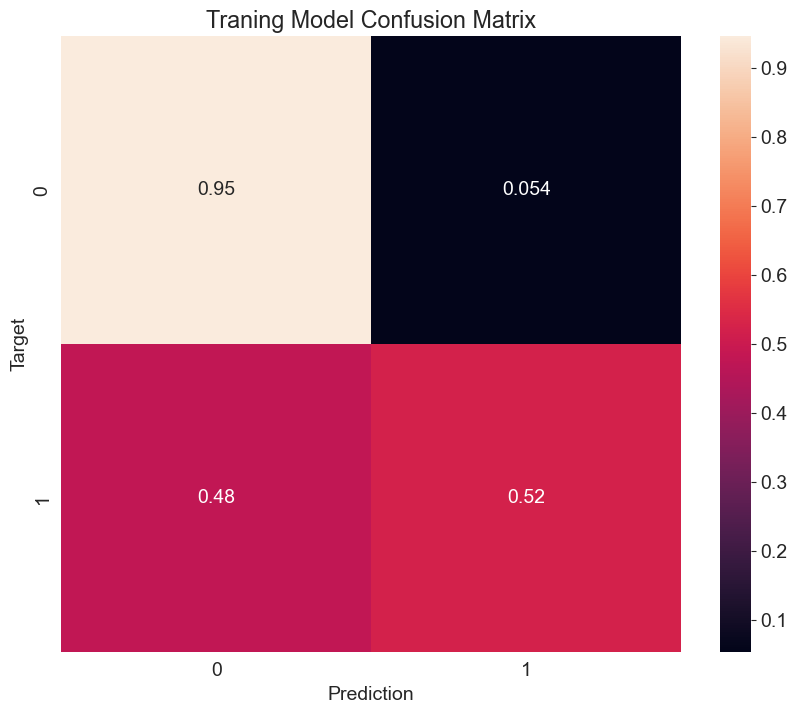

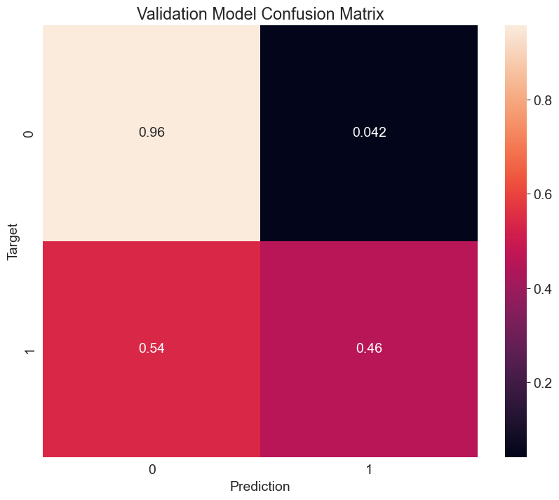

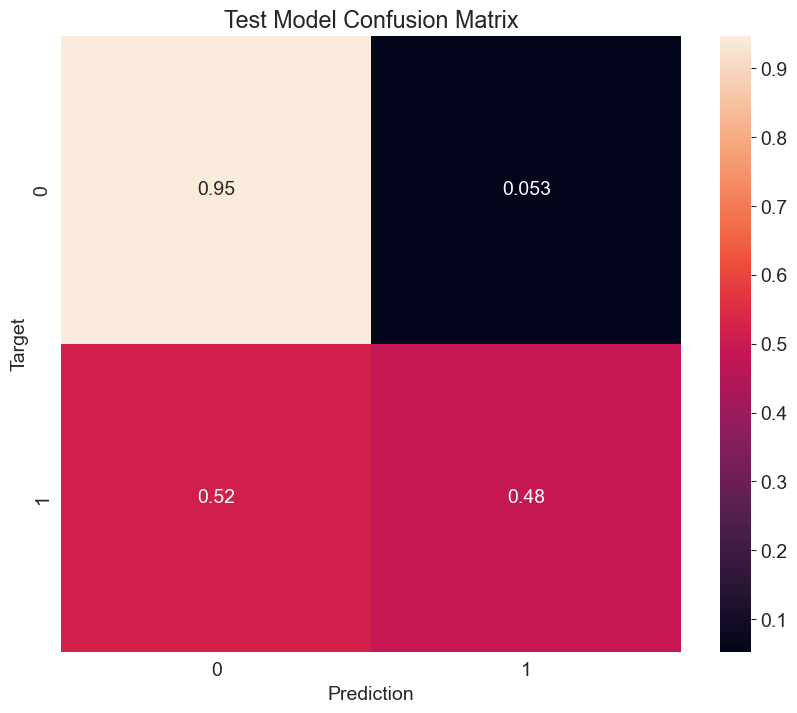

```python
predict_and_plot(X_train,train_targets , logistic_model , 'Traning')
predict_and_plot(X_val,val_targets , logistic_model, 'Validation')
predict_and_plot(X_test,test_targets , logistic_model , 'Test')
```

## Let's define a helper function to make predictions for individual inputs.

```python
def predict_input(new_input , model):
    input_df = pd.DataFrame([new_input])
    input_df[num_cols] = imputer.transform(input_df[num_cols])
    input_df[num_cols] = scaler.transform(input_df[num_cols])
    input_df[encoded_cols] = encoder.transform(input_df[cat_col])
    X_input = input_df[num_cols + encoded_cols]
    prediction = model.predict(X_input)[0]
    # probability = model.predict_proba(X_input)[0][1]
    print(f'Prediction of {model} :  {prediction} ')
    # print(f'Chances of Rain Tomorrow :  {probability * 100}% ')
```

```python
new_input = {'Date': '2021-06-19',
             'Location': 'Melbourne',
             'MinTemp': 23.2,
             'MaxTemp': 33.2,
             'Rainfall': 10.2,
             'Evaporation': 4.2,
             'Sunshine': np.nan,
             'WindGustDir': 'NNW',
             'WindGustSpeed': 52.0,
             'WindDir9am': 'NW',
             'WindDir3pm': 'NNE',
             'WindSpeed9am': 13.0,
             'WindSpeed3pm': 20.0,
             'Humidity9am': np.nan,
             'Humidity3pm': 58.0,
             'Pressure9am': 1004.8,
             'Pressure3pm': 1001.5,
             'Cloud9am': 8.0,
             'Cloud3pm': 5.0,
             'Temp9am': 25.7,
             'Temp3pm': 33.0,
             'RainToday': 'Yes'}
```

```python
predict_input(new_input , logistic_model)
```

```
Prediction of LogisticRegression(solver='newton-cg') :  Yes
```

```python
logistic_model.intercept_
```

```
array([-4.23388156])
```

```python
logistic_model.coef_
```

```
array([[ 8.75114263e-01, -2.87504290e+00,  3.16366158e+00,
         8.91727452e-01, -1.66350681e+00,  6.78671846e+00,
        -9.33544059e-01, -1.42762078e+00,  3.39780259e-01,
         6.01052756e+00,  5.48613073e+00, -9.16837396e+00,
        -1.58369538e-01,  1.29303017e+00,  4.97956481e-01,
         2.05558198e+00,  6.55899815e-01, -5.02799903e-01,
         5.28548861e-01,  5.84488967e-02,  3.96363404e-01,
        -3.04757024e-01,  2.30617994e-01,  4.91609103e-01,
         3.38371338e-02,  8.00632401e-02,  3.09525352e-01,
         2.69600627e-02,  8.12485446e-03, -4.38029674e-01,
        -9.04071244e-02, -5.18632970e-01, -7.41911824e-01,
        -2.03350828e-01, -2.76484256e-01, -5.17680457e-01,
         1.33281852e-01,  6.13114182e-02,  1.14784163e-01,
        -8.51381157e-01, -3.97248861e-01,  5.59358759e-02,
        -4.13273469e-01, -4.16420365e-01, -1.86031504e-02,
         2.40814083e-01,  5.00562817e-01,  6.60082454e-01,
         4.77764809e-01,  2.19137216e-02,  3.00972102e-01,
        -2.71318435e-01,  4.75324324e-01, -8.84953807e-03,
        -6.43110806e-02, -6.81380440e-01,  4.19240714e-01,
         2.33757382e-01,  2.36494219e-01,  2.35843519e-01,
        -1.96945007e-01,  6.59786867e-02,  7.54198479e-01,
        -7.52152515e-01, -1.42376582e-01, -1.84625374e-02,
        -1.52408648e-02,  8.07742688e-02, -7.93288790e-02,
        -8.86242525e-02, -1.77114765e-01, -2.15593247e-02,
        -1.47728466e-02,  3.28315487e-02,  1.10711168e-01,
         9.29321067e-02,  4.98377230e-02,  5.36656675e-02,
        -7.87043785e-02, -1.13614666e-01, -5.63174132e-02,
         2.42932120e-01, -1.75563546e-01,  1.13950467e-01,
        -1.84800746e-01,  1.73413069e-01,  1.22433070e-01,
         2.87509249e-01,  8.25988314e-02,  8.75823540e-02,
        -2.64299996e-01, -1.63927830e-01, -2.61419100e-01,
        -5.06250915e-02,  8.44302634e-02,  5.79044172e-02,
         8.79486706e-02,  1.28725249e-01, -1.25914654e-01,
        -9.63984457e-02, -8.96619618e-03, -9.16963207e-02,
         1.82398267e-01, -1.68033500e-01,  6.36268649e-02,
         4.29250924e-01,  3.67001408e-01, -1.21641898e-01,
        -9.80800910e-02, -2.23441141e-01, -1.72881243e-01,
        -2.25516293e-01, -3.55285430e-02,  1.11820906e-01,
        -1.31124204e-01,  2.19154183e-01, -2.48341205e-01,
         2.48285881e-01]])
```

```python
logistic_model_coefs_df = pd.DataFrame({
    'weight_name' : X_train.columns.to_list(),
    'coef_values' :  logistic_model.coef_[0] ,
    'bias_value'  : 4.23388156
})
px.bar(logistic_model_coefs_df , x = 'coef_values' , y = 'weight_name' , height= 2000 ,width=1000 )
```

[output not shown]

```python
df['Location'].unique()
```

```
array(['Albury', 'BadgerysCreek', 'Cobar', 'CoffsHarbour', 'Moree',
       'Newcastle', 'NorahHead', 'NorfolkIsland', 'Penrith', 'Richmond',
       'Sydney', 'SydneyAirport', 'WaggaWagga', 'Williamtown',
       'Wollongong', 'Canberra', 'Tuggeranong', 'MountGinini', 'Ballarat',
       'Bendigo', 'Sale', 'MelbourneAirport', 'Melbourne', 'Mildura',
       'Nhil', 'Portland', 'Watsonia', 'Dartmoor', 'Brisbane', 'Cairns',
       'GoldCoast', 'Townsville', 'Adelaide', 'MountGambier', 'Nuriootpa',
       'Woomera', 'Albany', 'Witchcliffe', 'PearceRAAF', 'PerthAirport',
       'Perth', 'SalmonGums', 'Walpole', 'Hobart', 'Launceston',
       'AliceSprings', 'Darwin', 'Katherine', 'Uluru'], dtype=object)
```

## Now using diffrent Model for prediction

SGDClassifier for making new Prediction https://scikit-learn.org/stable/modules/generated/sklearn.linear_model.SGDClassifier.html

```python
from sklearn.linear_model import SGDClassifier
```

```python
sgd_model = SGDClassifier(tol=1e-4 , max_iter=300000000 , random_state=2 , eta0= 0.0001 )
```

```python
sgd_model.fit(train_inputs[num_cols+encoded_cols] , train_targets)
```

```
SGDClassifier(eta0=0.0001, max_iter=300000000, random_state=2, tol=0.0001)
```

```python
train_preds = sgd_model.predict(train_inputs[num_cols+encoded_cols])
accuracy = accuracy_score(train_targets,train_preds)
print('Accuracy of SGDClassifier on Training data: ', accuracy*100,'%')
```

```
Accuracy of SGDClassifier on Training data:  85.19104380128178 %
```

```python
val_preds = sgd_model.predict(val_inputs[num_cols+encoded_cols])
accuracy = accuracy_score(val_targets,val_preds)
print('Accuracy of SGDClassifier on Validation data: ', accuracy*100,'%')
```

```
Accuracy of SGDClassifier on Validation data:  85.57551641406754 %
```

```python
test_preds = sgd_model.predict(test_inputs[num_cols+encoded_cols])
accuracy = accuracy_score(test_targets,test_preds)
print('Accuracy of SGDClassifier on Testing data: ', accuracy*100,'%')
```

```
Accuracy of SGDClassifier on Testing data:  84.14624659665499 %
```

```
Accuracy of SGDClassifier(eta0=0.0001, max_iter=300000000, random_state=2, tol=0.0001) on Training Dataset :  85.19104380128178 %
Accuracy of SGDClassifier(eta0=0.0001, max_iter=300000000, random_state=2, tol=0.0001) on Validation Dataset :  85.57551641406754 %
Accuracy of SGDClassifier(eta0=0.0001, max_iter=300000000, random_state=2, tol=0.0001) on Testing Dataset :  84.14624659665499 %
```

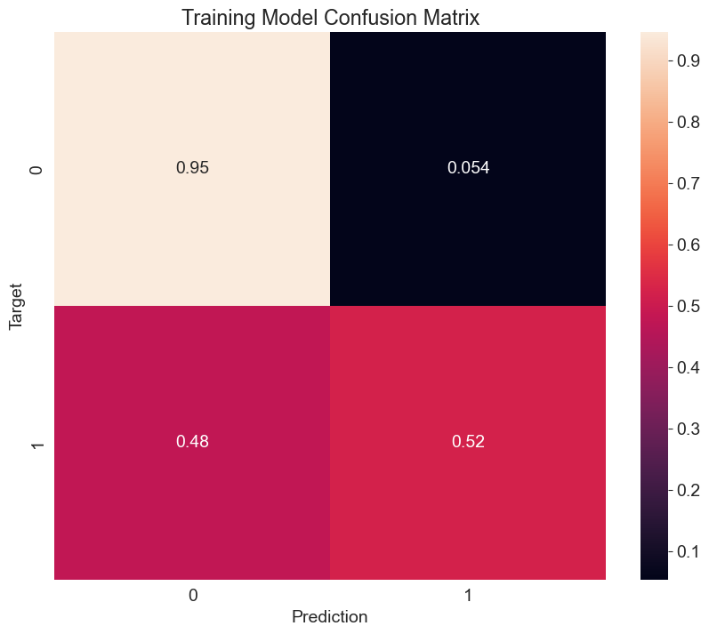

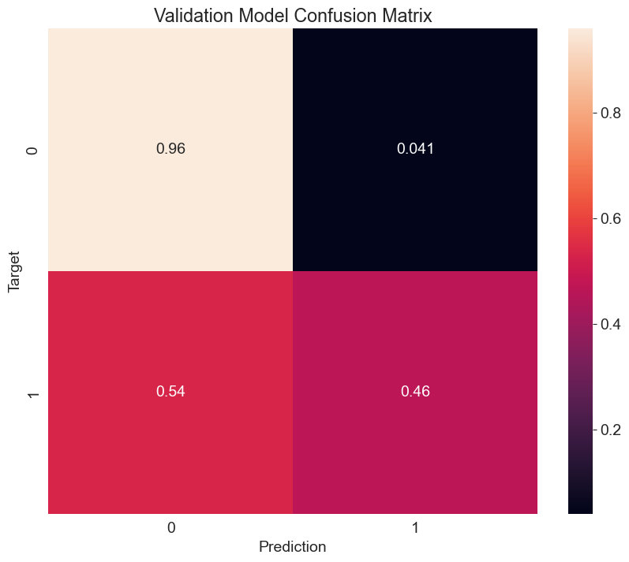

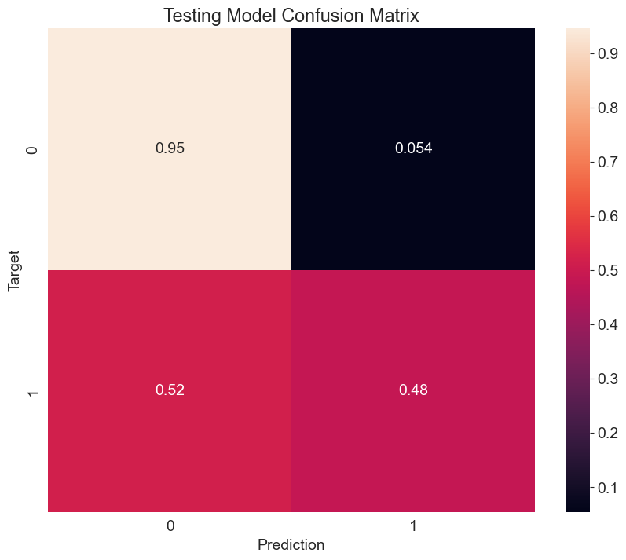

```python
predict_and_plot(X_train, train_targets , sgd_model , 'Training')
predict_and_plot(X_val, val_targets , sgd_model , 'Validation')
predict_and_plot(X_test, test_targets , sgd_model , 'Testing')
```

```python
X_train.columns.to_list()
```

```
['MinTemp',
 'MaxTemp',
 'Rainfall',
 'Evaporation',
 'Sunshine',
 'WindGustSpeed',
 'WindSpeed9am',
 'WindSpeed3pm',
 'Humidity9am',
 'Humidity3pm',
 'Pressure9am',
 'Pressure3pm',
 'Cloud9am',
 'Cloud3pm',
 'Temp9am',
 'Temp3pm',
 'Location_Adelaide',
 'Location_Albany',
 'Location_Albury',
 'Location_AliceSprings',
 'Location_BadgerysCreek',
 'Location_Ballarat',
 'Location_Bendigo',
 'Location_Brisbane',
 'Location_Cairns',
 'Location_Canberra',
 'Location_Cobar',
 'Location_CoffsHarbour',
 'Location_Dartmoor',
 'Location_Darwin',
 'Location_GoldCoast',
 'Location_Hobart',
 'Location_Katherine',
 'Location_Launceston',
 'Location_Melbourne',
 'Location_MelbourneAirport',
 'Location_Mildura',
 'Location_Moree',
 'Location_MountGambier',
 'Location_MountGinini',
```

[output cut: 63 more lines]

```
 'WindDir3pm_NE',
 'WindDir3pm_NNE',
 'WindDir3pm_NNW',
 'WindDir3pm_NW',
 'WindDir3pm_S',
 'WindDir3pm_SE',
 'WindDir3pm_SSE',
 'WindDir3pm_SSW',
 'WindDir3pm_SW',
 'WindDir3pm_W',
 'WindDir3pm_WNW',
 'WindDir3pm_WSW',
 'WindDir3pm_nan',
 'RainToday_No',
 'RainToday_Yes']
```

```python
sgd_model.coef_
```

```
array([[-1.49155389e-01, -4.97491193e-01,  2.27866578e+00,
         6.69474022e-01, -1.06029930e+00,  4.36178035e+00,
        -4.10804240e-01, -1.22444061e+00, -4.12426053e-02,
         4.24725351e+00,  1.68043386e+00, -3.98961815e+00,
        -5.96447932e-02,  5.81755488e-01, -1.37658017e-01,
         8.96173349e-01,  4.37565917e-01, -3.72814010e-01,
         3.31608251e-01,  2.19764048e-01,  2.41348017e-01,
        -2.04066616e-01,  1.64823036e-01,  3.64965294e-01,
         8.43736970e-02,  3.92435800e-02,  3.21797356e-01,
        -1.37352530e-02, -1.56974320e-01, -7.45628020e-02,
        -7.45628020e-02, -4.68960781e-01, -2.80591597e-01,
        -2.55083270e-01, -1.43239067e-01, -3.68889652e-01,
         1.68747394e-01,  2.06028795e-01,  1.96217900e-02,
        -6.41632533e-01, -2.02104437e-01,  5.69031910e-02,
        -3.72814010e-01, -2.84515955e-01, -2.55083270e-02,
         2.72742881e-01,  3.31608251e-01,  4.49338991e-01,
         3.57116578e-01, -3.13948640e-02,  2.41348017e-01,
        -2.19764048e-01,  2.62931986e-01,  4.12057590e-02,
         1.37352530e-02, -2.92364671e-01,  1.92293542e-01,
         2.66856344e-01,  1.41276888e-01, -5.29788330e-02,
        -1.49125604e-01,  3.72814010e-02,  4.10095411e-01,
        -5.35674867e-01,  1.17730740e-02,  5.49410120e-02,
         3.13948640e-02,  1.17730740e-01, -5.69031910e-02,
        -2.74705060e-02, -7.65249810e-02,  2.35461480e-02,
         1.37352530e-02,  1.02033308e-01,  1.13806382e-01,
         9.02602340e-02,  7.06384440e-02,  7.26006230e-02,
        -3.13948640e-02, -7.26006230e-02, -1.17730740e-02,
         5.10166540e-02, -3.53192220e-02,  1.39314709e-01,
        -1.96217900e-02,  9.41845920e-02,  1.07919845e-01,
         1.64823036e-01,  5.69031910e-02,  1.00071129e-01,
        -1.11844203e-01, -7.45628020e-02, -1.09882024e-01,
        -1.96217900e-03,  7.06384440e-02,  2.55083270e-02,
         5.49410120e-02,  7.45628020e-02, -7.06384440e-02,
        -6.08275490e-02,  2.55083270e-02, -3.92435800e-02,
         1.23617277e-01, -5.69031910e-02,  2.94326850e-02,
         3.31608251e-01,  3.13948640e-01, -2.74705060e-02,
        -5.29788330e-02, -1.37352530e-01, -1.21655098e-01,
        -7.26006230e-02,  1.96217900e-03,  1.23617277e-01,
        -3.72814010e-02,  1.21655098e-01,  6.47519070e-02,
         4.00284516e-01]])
```

```python
logistic_model.intercept_
```

```
array([-4.23388156])
```

```python
sgd_model_coefs_df = pd.DataFrame({
    'weight_name' : X_train.columns.to_list(),
    'coef_values' :  logistic_model.coef_[0] ,
    'bias_value'  : -4.2339095
})
sgd_model_coefs_df.to_csv('csv\\sgd_model_coefs_df.csv')
px.bar(logistic_model_coefs_df , x = 'coef_values' , y = 'weight_name' , height= 2000 ,width=1000 )
```

[output not shown]

```python
sgd_model.intercept_
```

```
array([-2.80555372])
```

```python
predict_input(new_input, sgd_model)
```

```
Prediction of SGDClassifier(eta0=0.0001, max_iter=300000000, random_state=2, tol=0.0001) :  Yes
```

## Saving and Loading Trained Models

We can save the parameters (weights and biases) of our trained model to disk, so that we needn't retrain the model from scratch each time we wish to use it. Along with the model, it's also important to save imputers, scalers, encoders and even column names. Anything that will be required while generating predictions using the model should be saved.

We can use the `joblib` module to save and load Python objects on the disk.

```python
import joblib
```

```python
aussie_rain_logistic_model = {
    'model': logistic_model,
    'imputer': imputer,
    'scaler': scaler,
    'encoder': encoder,
    'input_cols': input_col,
    'target_col': target_col,
    'numeric_cols': num_cols,
    'categorical_cols': cat_col,
    'encoded_cols': encoded_cols
}
```

```python
aussie_rain_sgd_model = {
    'model': sgd_model,
    'imputer': imputer,
    'scaler': scaler,
    'encoder': encoder,
    'input_cols': input_col,
    'target_col': target_col,
    'numeric_cols': num_cols,
    'categorical_cols': cat_col,
    'encoded_cols': encoded_cols
}
```

```python
joblib.dump(aussie_rain_logistic_model , "files\\aussie_rain_logistic_model.joblib")
```

```
['files\\aussie_rain_logistic_model.joblib']
```

```python
joblib.dump(aussie_rain_sgd_model , "files\\aussie_rain_sgd_model.joblib")
```

```
['files\\aussie_rain_sgd_model.joblib']
```

```python
aussie_rain_logistic_model = joblib.load('files\\aussie_rain_logistic_model.joblib')
```

```python
aussie_rain_logistic_model
```

```
{'model': LogisticRegression(solver='newton-cg'),
 'imputer': SimpleImputer(),
 'scaler': MinMaxScaler(),
 'encoder': OneHotEncoder(handle_unknown='ignore', sparse=False, sparse_output=False),
 'input_cols': ['Location',
  'MinTemp',
  'MaxTemp',
  'Rainfall',
  'Evaporation',
  'Sunshine',
  'WindGustDir',
  'WindGustSpeed',
  'WindDir9am',
  'WindDir3pm',
  'WindSpeed9am',
  'WindSpeed3pm',
  'Humidity9am',
  'Humidity3pm',
  'Pressure9am',
  'Pressure3pm',
  'Cloud9am',
  'Cloud3pm',
  'Temp9am',
  'Temp3pm',
  'RainToday'],
 'target_col': 'RainTomorrow',
 'numeric_cols': ['MinTemp',
  'MaxTemp',
  'Rainfall',
  'Evaporation',
  'Sunshine',
  'WindGustSpeed',
  'WindSpeed9am',
  'WindSpeed3pm',
  'Humidity9am',
  'Humidity3pm',
  'Pressure9am',
  'Pressure3pm',
  'Cloud9am',
  'Cloud3pm',
```

[output cut: 94 more lines]

```
  'WindDir3pm_NE',
  'WindDir3pm_NNE',
  'WindDir3pm_NNW',
  'WindDir3pm_NW',
  'WindDir3pm_S',
  'WindDir3pm_SE',
  'WindDir3pm_SSE',
  'WindDir3pm_SSW',
  'WindDir3pm_SW',
  'WindDir3pm_W',
  'WindDir3pm_WNW',
  'WindDir3pm_WSW',
  'WindDir3pm_nan',
  'RainToday_No',
  'RainToday_Yes']}
```

```python
test_preds2 = aussie_rain_logistic_model['model'].predict(X_test)
accuracy_score(test_targets, test_preds2)*100
```

```
84.21625826526643
```

```python
aussie_rain_sgd_model = joblib.load('files\\aussie_rain_sgd_model.joblib')
```

```python
test_preds3 = aussie_rain_sgd_model['model'].predict(X_test)
accuracy_score(test_targets, test_preds2)*100
```

```
84.21625826526643
```